# *RMeDPower2*: helping design and analyses of data from repeated measures experiments

#### 2.2.1.2 Associations with hippocampus volume

Next, we can first ask the question whether or not the proportion of nuclei derived from each of the mice are associated with their hippocampus volumes. Note, more neuro-degeneration is linked to smaller hippocampus volumes. More exactly, we want to test whether or not there is a change in the log odds of cluster membership in cluster 7 corresponding to a unit change in the hippocampus volume. The above data provided includes the hippocampus volume for each mouse.

```r
##Associations of cell-type proportions with hippocampus volume
template_dir <- system.file("input_templates/single_cell_data/celltype_hippocampus", package = "RMeDPower2")

design <- readDesign(file.path(template_dir, "design_celltype.json"))

diagnose_res <- diagnoseDataModel(data, design, model)
```

To identify all the models fit to the data. There were outliers identified so two models were fit with and without outliers.

```r
print(diagnose_res$models)
```

```
## [1] "Natural scale"             "Natural scale wo outliers"
```

Let us look the basic QC plots for the models fit in the natural scale of the responses. There are only two levels for the animal model. So cooks distance estimates not generated for them.

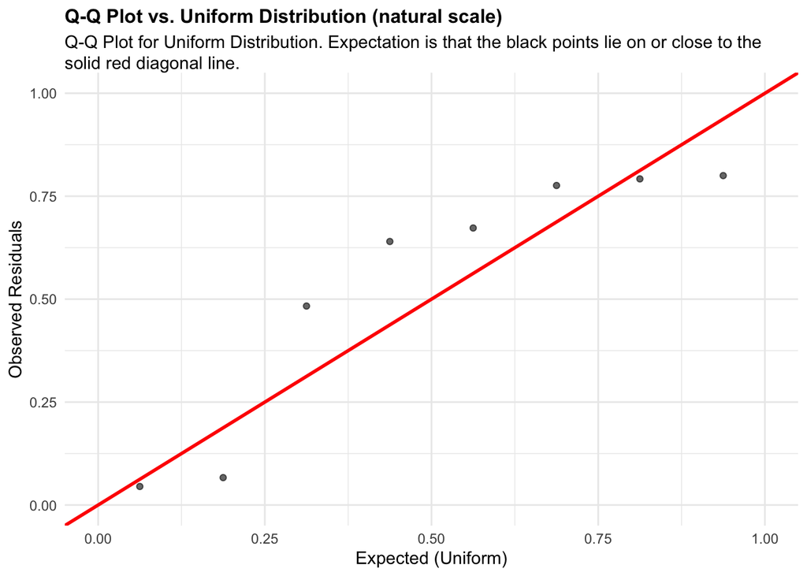

```r
plots <- diagnose_res$diagnostic_plots$natural_scale$plots
captions <- diagnose_res$diagnostic_plots$natural_scale$captions
for (i in seq_along(plots)) {
  print(plots[[i]])
    cat(sprintf("\n\n\n**Figure %d:** %s. %s\n\n", plot_no,names(plots)[i], captions[i]))
  plot_no <- plot_no + 1
}
```

**Figure 30:** residuals_QQ. Q-Q Plot for Uniform Distribution. Expectation is that the black points lie on or close to the solid red diagonal line. Check the Q-Q plots for good and bad examples here: https://library.virginia.edu/data/articles/diagnostic-plots

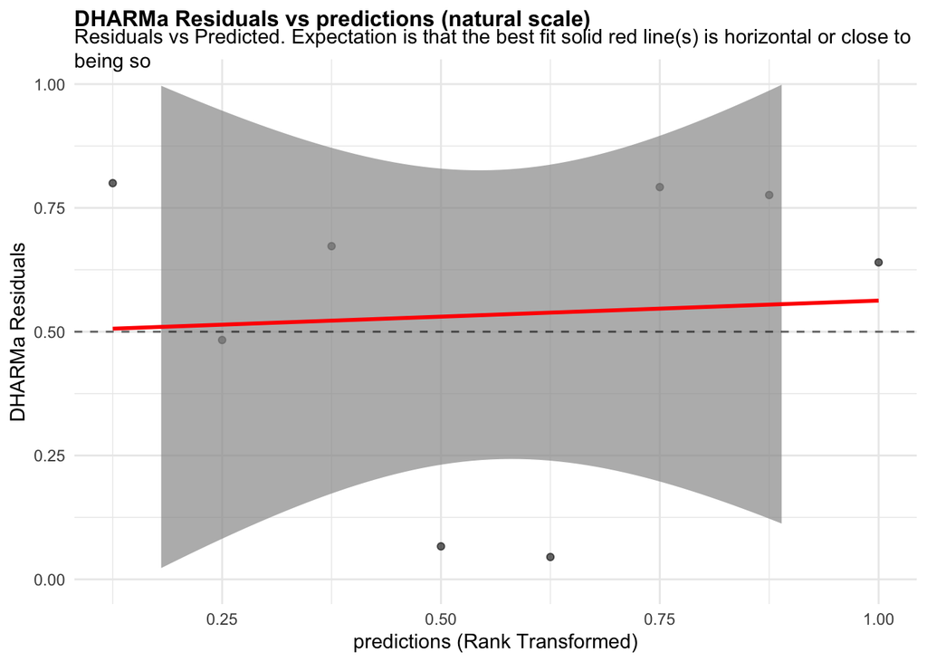

**Figure 31:** residuals_vs_predicted. Residuals vs Predicted Check the Residuals vs Fitted plots for good and bad examples here: https://library.virginia.edu/data/articles/diagnostic-plots

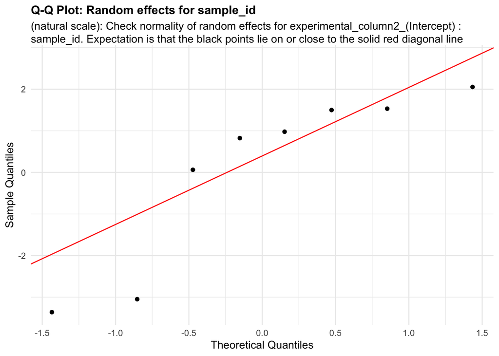

**Figure 32:** random_effects_QQ_1. Check normality of random effects for experimental_column2_(Intercept) (natural scale): sample_id. Expectation is that the black points lie on or close to the solid red diagonal line. Check the Normal Q-Q plots for good and bad examples here: https://library.virginia.edu/data/articles/diagnostic-plots

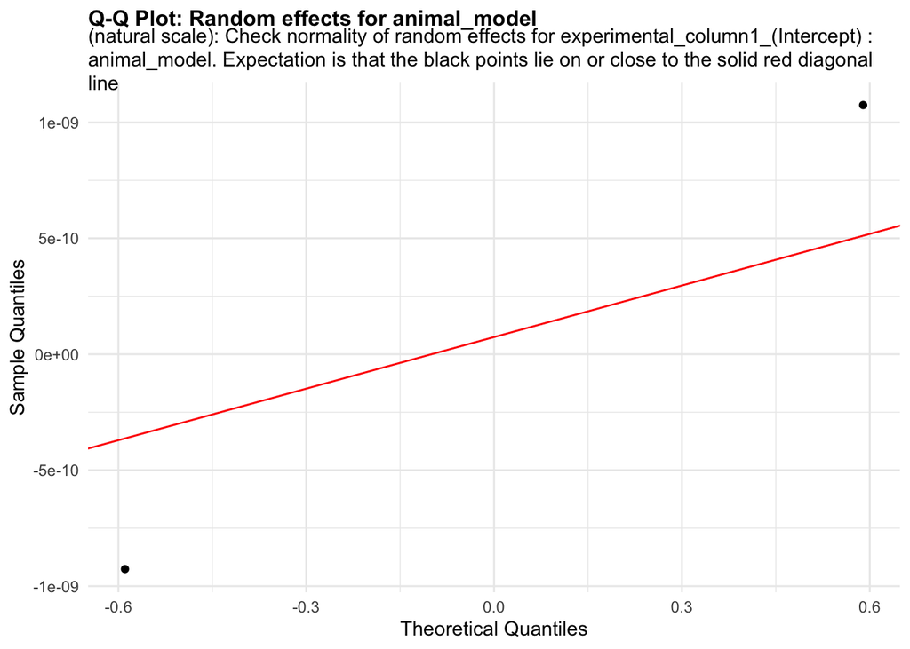

**Figure 33:** random_effects_QQ_2. Check normality of random effects for experimental_column1_(Intercept) (natural scale): animal_model. Expectation is that the black points lie on or close to the solid red diagonal line. Check the Normal Q-Q plots for good and bad examples here: https://library.virginia.edu/data/articles/diagnostic-plots

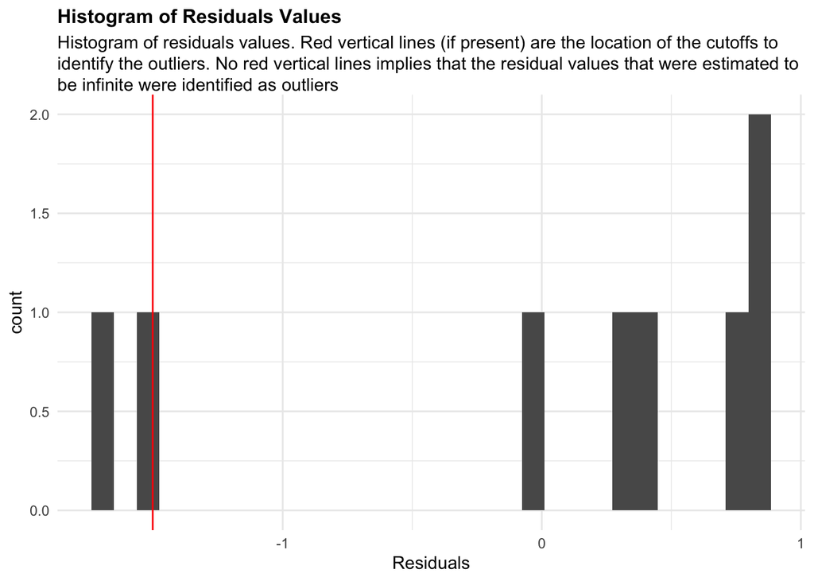

**Figure 34:** residuals_histogram. Histogram of residuals values. Red vertical lines (if present) are the location of the cutoffs to identify the outliers. No red vertical lines implies that the residual values that were estimated to be infinite were identified as outliers

```r
cat("\n\n\n")
```

Let us also now look at the QC plots after removing the identified outliers

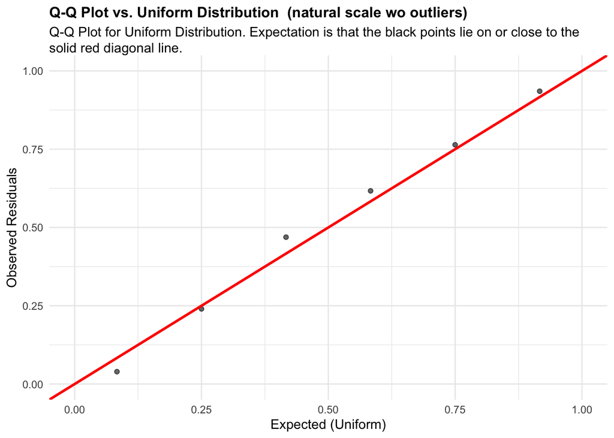

```r
plots <- diagnose_res$diagnostic_plots$natural_scale_wo_outliers$plots
captions <- diagnose_res$diagnostic_plots$natural_scale_wo_outliers$captions

for (i in seq_along(plots)) {
  print(plots[[i]])
    cat(sprintf("\n\n\n**Figure %d:** %s. %s\n\n", plot_no,names(plots)[i], captions[i]))
  plot_no <- plot_no + 1
}
```

**Figure 35:** residuals_QQ. Q-Q Plot for Uniform Distribution. Expectation is that the black points lie on or close to the solid red diagonal line. Check the Q-Q plots for good and bad examples here: https://library.virginia.edu/data/articles/diagnostic-plots

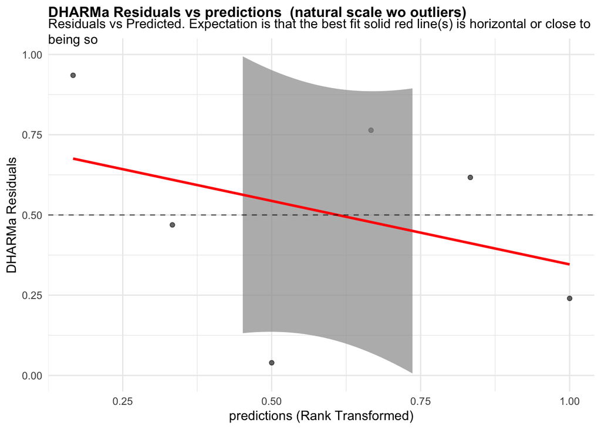

**Figure 36:** residuals_vs_predicted. Residuals vs Predicted Check the Residuals vs Fitted plots for good and bad examples here: https://library.virginia.edu/data/articles/diagnostic-plots

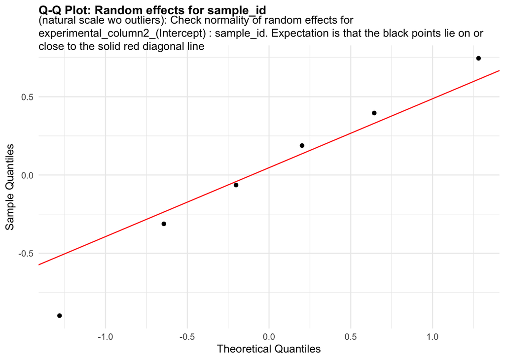

**Figure 37:** random_effects_QQ_1. Check normality of random effects for experimental_column2_(Intercept) (natural scale wo outliers): sample_id. Expectation is that the black points lie on or close to the solid red diagonal line. Check the Normal Q-Q plots for good and bad examples here: https://library.virginia.edu/data/articles/diagnostic-plots

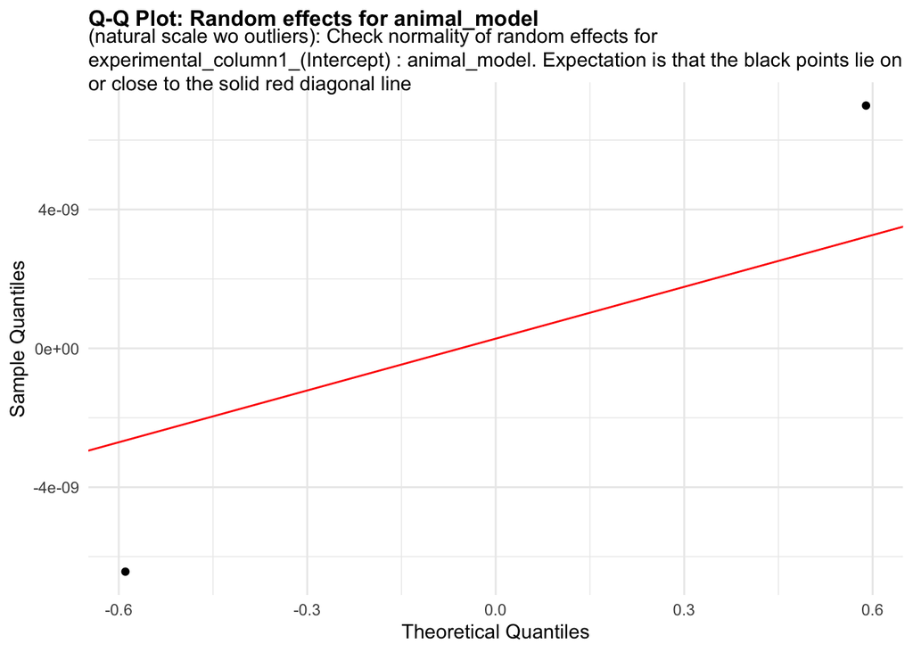

**Figure 38:** random_effects_QQ_2. Check normality of random effects for experimental_column1_(Intercept) (natural scale wo outliers): animal_model. Expectation is that the black points lie on or close to the solid red diagonal line. Check the Normal Q-Q plots for good and bad examples here: https://library.virginia.edu/data/articles/diagnostic-plots

```r
cat("\n\n\n")
```

We can also estimate the parameter of interest - log odds ratio of cluster 7 membership per unit increase in hippocampus volume of associated mouse.

```
## Generalized linear mixed model fit by maximum likelihood (Laplace
##   Approximation) [glmerMod]
##  Family: binomial  ( logit )
## Formula:
## cbind(response_column, (total_column - response_column)) ~ condition_column +
##     covariate + (1 | experimental_column1) + (1 | experimental_column2)
##    Data: data.update
##
##       AIC       BIC    logLik -2*log(L)  df.resid
##     105.2     105.6     -47.6      95.2         3
##
## Scaled residuals:
##      Min       1Q   Median       3Q      Max
## -0.57752 -0.13043  0.00696  0.02846  0.06210
##
## Random effects:
##  Groups               Name        Variance  Std.Dev.
##  experimental_column2 (Intercept) 4.375e+00 2.092e+00
##  experimental_column1 (Intercept) 1.201e-09 3.465e-05
## Number of obs: 8, groups:  experimental_column2, 8; experimental_column1, 2
##
## Fixed effects:
##                  Estimate Std. Error z value Pr(>|z|)
## (Intercept)       -0.2808     2.5583  -0.110   0.9126
## condition_column  -0.6509     0.3375  -1.929   0.0538 .
## covariateM        -0.6567     1.5057  -0.436   0.6628
## ---
## Signif. codes:  0 '***' 0.001 '**' 0.01 '*' 0.05 '.' 0.1 ' ' 1
##
## Correlation of Fixed Effects:
##             (Intr) cndtn_
## condtn_clmn -0.910
## covariateM  -0.274 -0.021
## optimizer (Nelder_Mead) convergence code: 0 (OK)
## boundary (singular) fit: see help('isSingular')
```

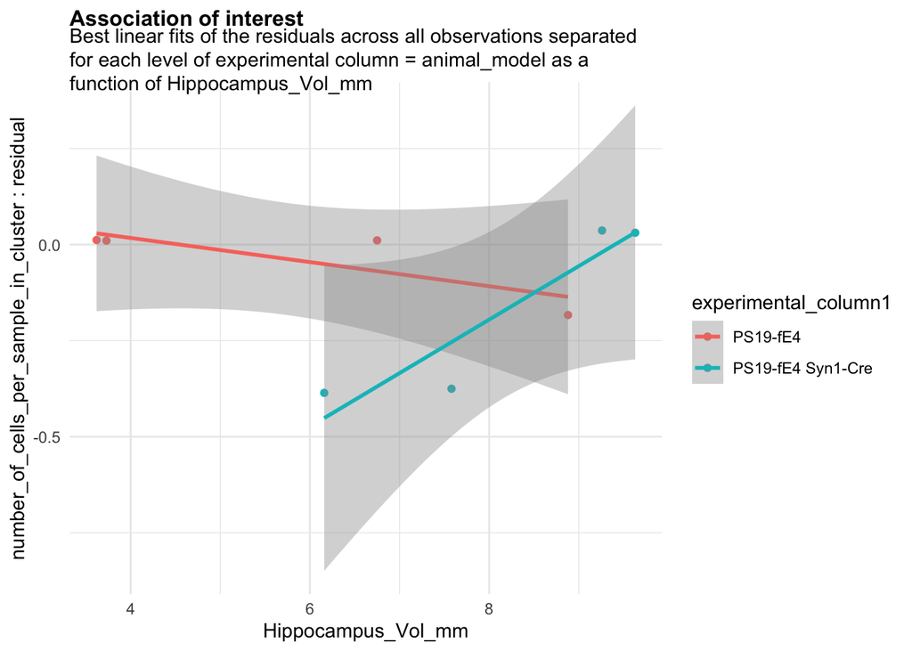

```r
estimate_res <- getEstimatesOfInterest(data, design, model,print_plots = F)
print(estimate_res[[1]])
```

**Figure 39:**

And calculate the statistical power to estimate this association for different numbers of animals per group.

```r
power_res <- calculatePower(data, design, model, power_param)
```

[[1]]

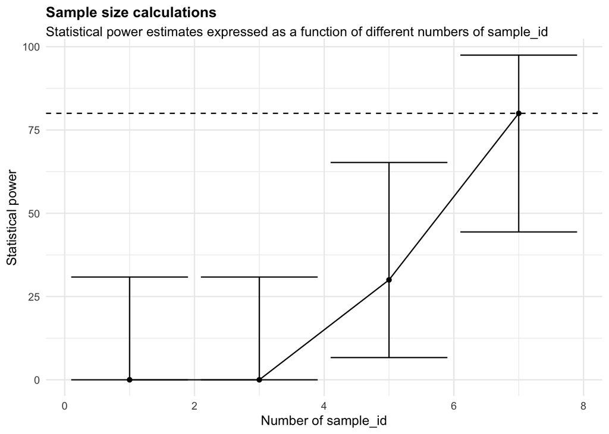

**Figure 40:**

### 2.2.2 Gene expression associations with genotype

We will now estimate the association of the expression levels of the Snhg11 gene with genotype among cells in cluster 7 in the same data set. We will now load the raw counts for this gene and create the relevant RMeDesign, ProbabilityModel and PowerParams objects.

```r
template_dir <- system.file("input_templates/single_cell_data/gene_expression", package = "RMeDPower2")

data <- snRNAseq_gene_count_data
head(data)
```

```
##    y    orig.ident nCount_RNA nFeature_RNA percent.mt sample_number
## 1 20 SeuratProject       2878         1716 0.03474635           S10
## 2  6 SeuratProject       9350         3682 0.05347594           S10
## 3 22 SeuratProject       2949         1735 0.03390980           S10
## 4 12 SeuratProject       4529         2494 0.04415986           S10
## 5 14 SeuratProject       3044         1866 0.03285151           S10
## 6  9 SeuratProject      10636         3957 0.03760812           S10
##   mouse_number genotype sex Cre ApoE      dob age_perfused date_perfused
## 1          154 PS19-fE4   F   - E4/4 10/30/19         10.3        9/7/20
## 2          154 PS19-fE4   F   - E4/4 10/30/19         10.3        9/7/20
## 3          154 PS19-fE4   F   - E4/4 10/30/19         10.3        9/7/20
## 4          154 PS19-fE4   F   - E4/4 10/30/19         10.3        9/7/20
## 5          154 PS19-fE4   F   - E4/4 10/30/19         10.3        9/7/20
## 6          154 PS19-fE4   F   - E4/4 10/30/19         10.3        9/7/20
##   date_of_nuclear_isolation nCount_SCT nFeature_SCT SCT_snn_res.0.7
```

[output cut: 20 more lines]

```r
design <- readDesign(file.path(template_dir, "design_gene_expression.json"))
print(design)
```

```
## An object of class "RMeDesign"
## Slot "response_column":
## [1] "y"
##
## Slot "covariate":
## [1] "sex"
##
## Slot "condition_column":
## [1] "genotype"
##
## Slot "condition_is_categorical":
## [1] TRUE
##
## Slot "experimental_columns":
## [1] "sample_number"
##
## Slot "crossed_columns":
## NULL
##
## Slot "total_column":
## [1] "library_size"
##
## Slot "outlier_alpha":
## [1] 0.05
##
## Slot "na_action":
## [1] "complete"
##
## Slot "include_interaction":
## [1] FALSE
##
## Slot "random_slope_variable":
## NULL
##
## Slot "covariate_is_categorical":
## [1] TRUE
```

```r
model <- readProbabilityModel(file.path(template_dir, "prob_model.json"))
print(model)
```

```
## An object of class "ProbabilityModel"
## Slot "error_is_non_normal":
## [1] TRUE
##
## Slot "family_p":
## [1] "negative_binomial"
```

```r
power_param <- readPowerParams(file.path(template_dir, "power_param.json"))
print(power_param)
```

```
## An object of class "PowerParams"
## Slot "target_columns":
## [1] "sample_number"
##
## Slot "power_curve":
## [1] 1
##
## Slot "nsimn":
## [1] 10
##
## Slot "levels":
## [1] 1
##
## Slot "max_size":
## [1] 1
##
## Slot "alpha":
## [1] 0.05
##
## Slot "breaks":
## NULL
##
## Slot "effect_size":
## NULL
##
## Slot "icc":
## NULL
```

Note, we will assume the underlying probability distribution for the counts is negative binomial and will control for differences in the sequencing depths or the total reads each cell receives using `library_size`.

Diagnosis of the data and the model

```r
diagnose_res <- diagnoseDataModel(data, design, model)
```

To identify all the models fit to the data. There were outliers identified so two models were fit in the natural scale.

```r
print(diagnose_res$models)
```

```
## [1] "Natural scale"             "Natural scale wo outliers"
```

Let us look the basic QC plots for the models fit in the natural scale of the responses.

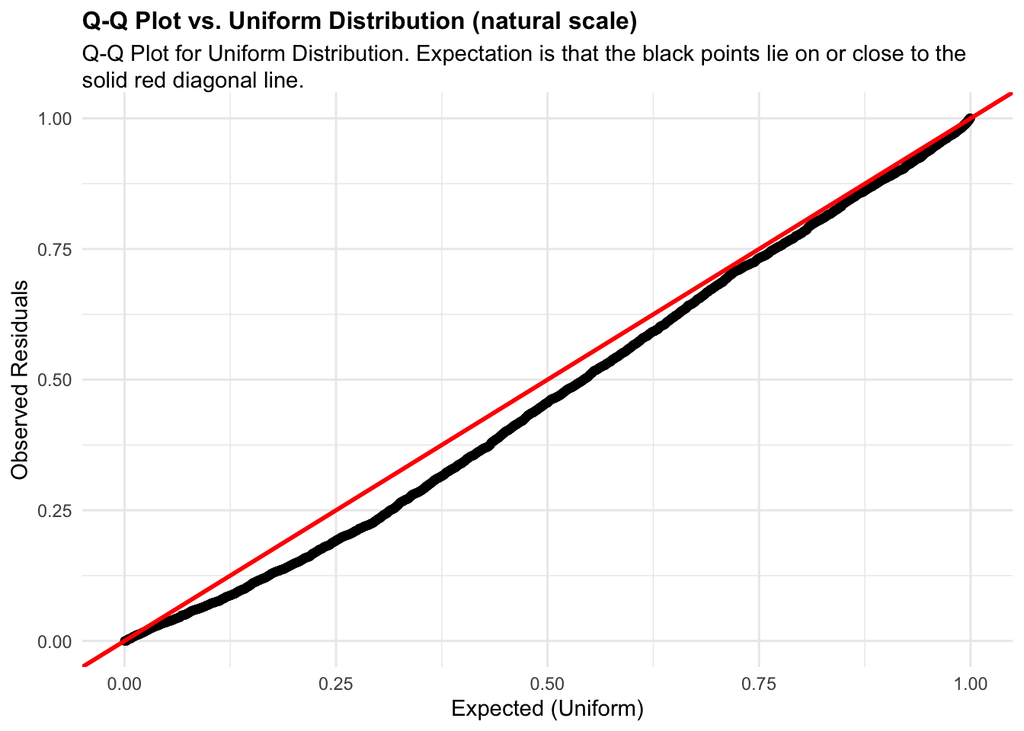

```r
plots <- diagnose_res$diagnostic_plots$natural_scale$plots
captions <- diagnose_res$diagnostic_plots$natural_scale$captions

for (i in seq_along(plots)) {
  print(plots[[i]])
    cat(sprintf("\n\n\n**Figure %d:** %s. %s\n\n", plot_no,names(plots)[i], captions[i]))
  plot_no <- plot_no + 1
}
```

**Figure 41:** residuals_QQ. Q-Q Plot for Uniform Distribution. Expectation is that the black points lie on or close to the solid red diagonal line. Check the Q-Q plots for good and bad examples here: https://library.virginia.edu/data/articles/diagnostic-plots

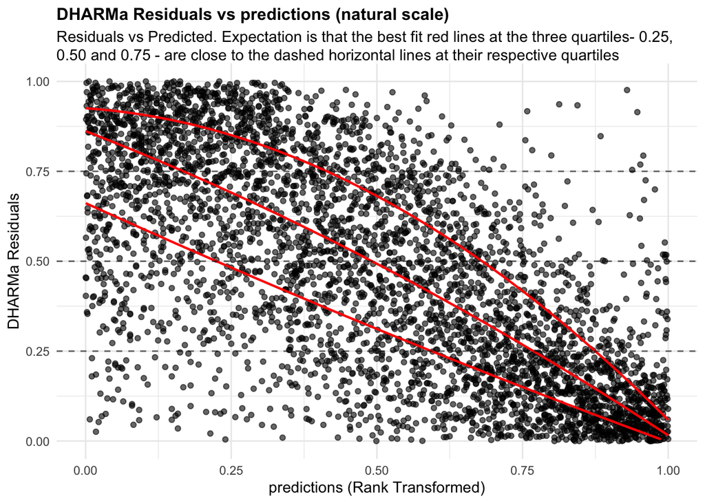

**Figure 42:** residuals_vs_predicted. Residuals vs Predicted Check the Residuals vs Fitted plots for good and bad examples here: https://library.virginia.edu/data/articles/diagnostic-plots

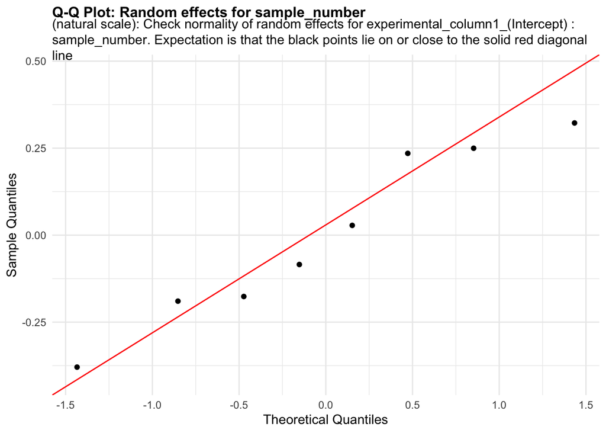

**Figure 43:** random_effects_QQ_1. Check normality of random effects for experimental_column1_(Intercept) (natural scale): sample_number. Expectation is that the black points lie on or close to the solid red diagonal line. Check the Normal Q-Q plots for good and bad examples here: https://library.virginia.edu/data/articles/diagnostic-plots

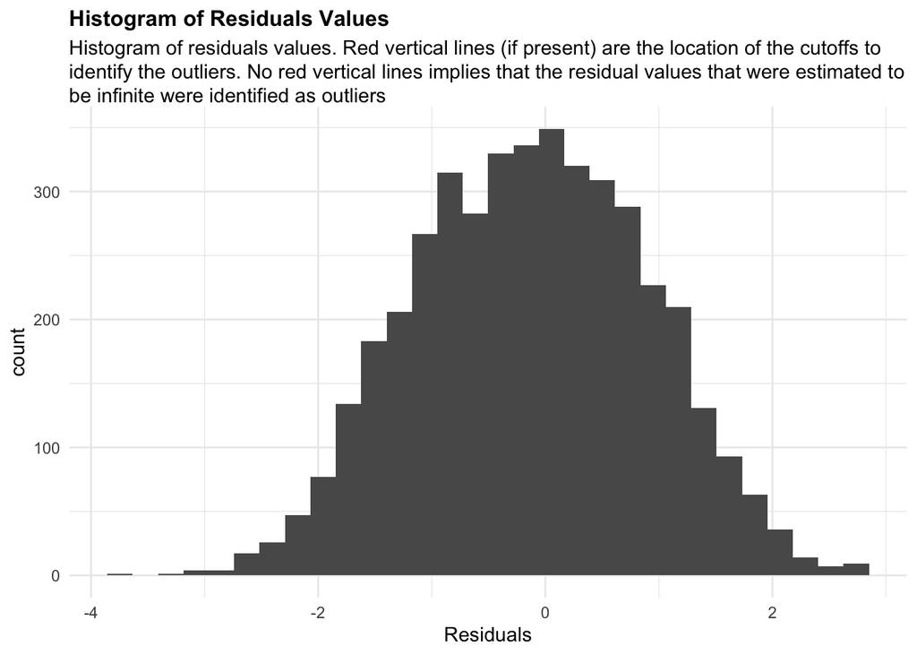

**Figure 44:** residuals_histogram. Histogram of residuals values. Red vertical lines (if present) are the location of the cutoffs to identify the outliers. No red vertical lines implies that the residual values that were estimated to be infinite were identified as outliers

```r
cooks_plots <- diagnose_res$cooks_plots$natural_scale
cat("\n\n\n")
```

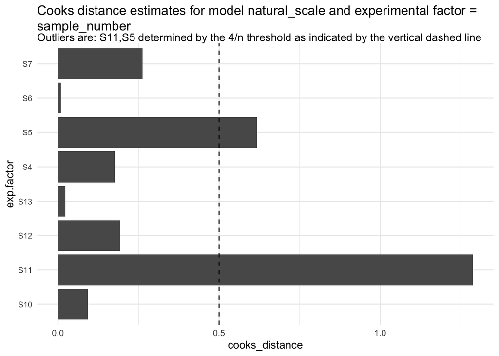

```r
for(i in 1:length(cooks_plots)) {
  print(cooks_plots[[i]])
  cat(sprintf("\n\n\n**Figure %d:**\n\n", plot_no))
  plot_no <- plot_no + 1
}
```

**Figure 45:**

```r
print("Inferred outlier groups are")
```

[1] “Inferred outlier groups are”

```r
print(diagnose_res$inferred_outlier_groups$natural_scale)
```

$sample_number [1] “S11” “S5”

Let us also now look at the QC plots after removing the identified outliers

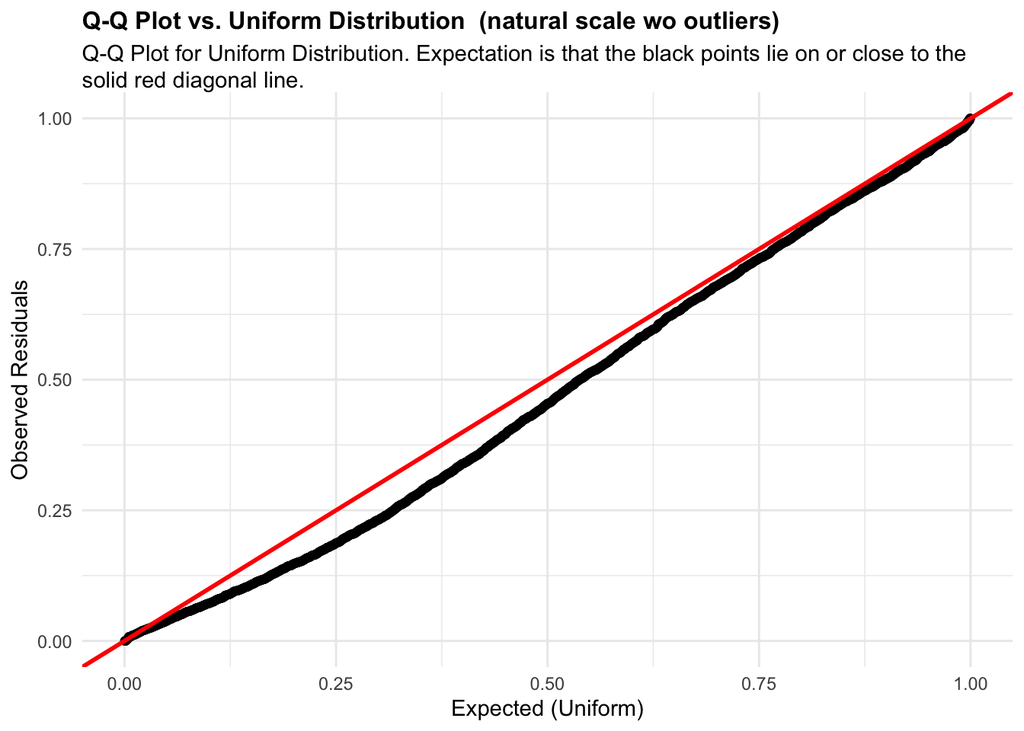

```r
plots <- diagnose_res$diagnostic_plots$natural_scale_wo_outliers$plots
captions <- diagnose_res$diagnostic_plots$natural_scale_wo_outliers$captions

for (i in seq_along(plots)) {
  print(plots[[i]])
    cat(sprintf("\n\n\n**Figure %d:** %s. %s\n\n", plot_no,names(plots)[i], captions[i]))
  plot_no <- plot_no + 1
}
```

**Figure 46:** residuals_QQ. Q-Q Plot for Uniform Distribution. Expectation is that the black points lie on or close to the solid red diagonal line. Check the Q-Q plots for good and bad examples here: https://library.virginia.edu/data/articles/diagnostic-plots

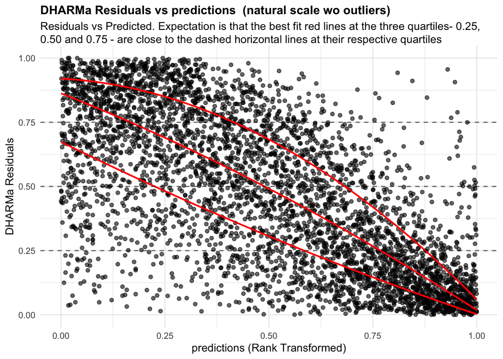

**Figure 47:** residuals_vs_predicted. Residuals vs Predicted Check the Residuals vs Fitted plots for good and bad examples here: https://library.virginia.edu/data/articles/diagnostic-plots

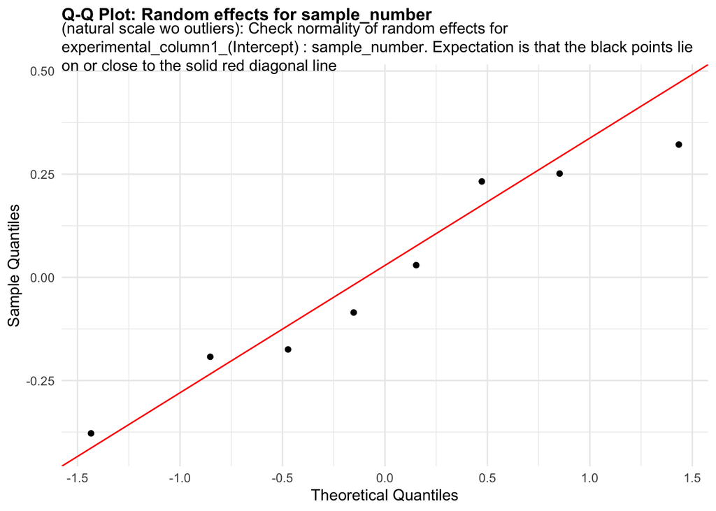

**Figure 48:** random_effects_QQ_1. Check normality of random effects for experimental_column1_(Intercept) (natural scale wo outliers): sample_number. Expectation is that the black points lie on or close to the solid red diagonal line. Check the Normal Q-Q plots for good and bad examples here: https://library.virginia.edu/data/articles/diagnostic-plots

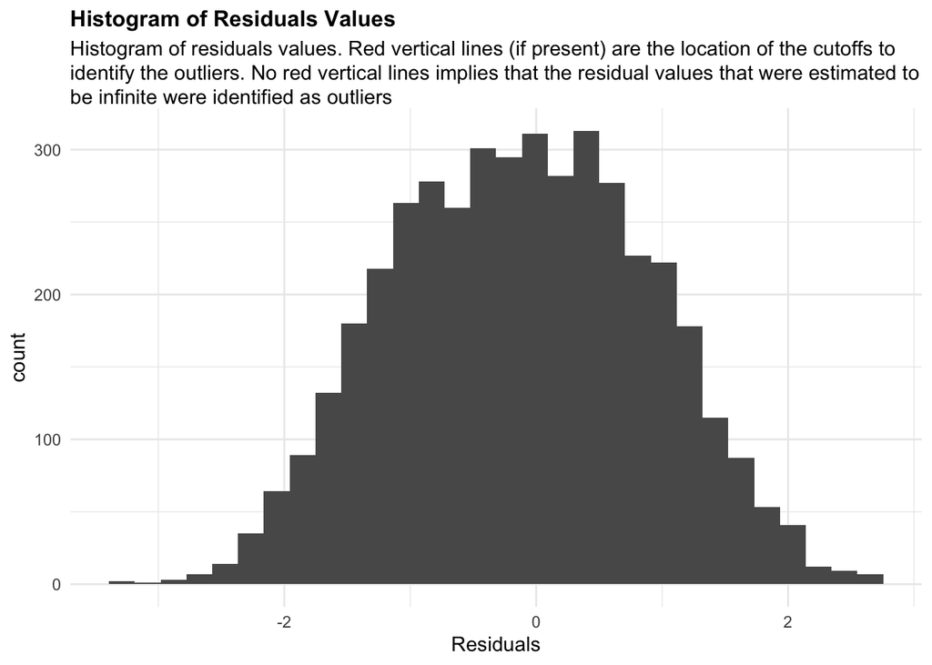

**Figure 49:** residuals_histogram. Histogram of residuals values. Red vertical lines (if present) are the location of the cutoffs to identify the outliers. No red vertical lines implies that the residual values that were estimated to be infinite were identified as outliers

```r
cooks_plots <- diagnose_res$cooks_plots$natural_scale_wo_outliers
cat("\n\n\n")
```

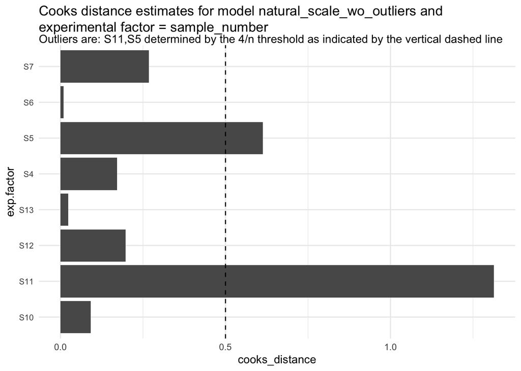

```r
for(i in 1:length(cooks_plots)) {
  print(cooks_plots[[i]])
  cat(sprintf("\n\n\n**Figure %d:**\n\n", plot_no))
  plot_no <- plot_no + 1
}
```

**Figure 50:**

```r
print("Inferred outlier groups are")
```

[1] “Inferred outlier groups are”

```r
print(diagnose_res$inferred_outlier_groups$natural_scale)
```

$sample_number [1] “S11” “S5”

We don’t see a good fit to the assumption of negative binomial distribution based on the residual vs predicted plots suggesting that GLMM models for single cell RNA-seq data, even though they have been proposed as alternatives to dealing with the issue of pseudo-replication, are not good models to assess for differential expression.

Estimate log-fold change of the Snhg11 gene with genotype.

```
## Generalized linear mixed model fit by maximum likelihood (Laplace
##   Approximation) [glmerMod]
##  Family: Negative Binomial(4.914)  ( log )
## Formula:
## response_column ~ condition_column + covariate + (1 | experimental_column1) +
##     offset(log(total_column))
##    Data: data.update
##
##       AIC       BIC    logLik -2*log(L)  df.resid
##   28790.0   28821.9  -14390.0   28780.0      4297
##
## Scaled residuals:
##     Min      1Q  Median      3Q     Max
## -1.8485 -0.7485 -0.1820  0.5882  5.4549
##
## Random effects:
##  Groups               Name        Variance Std.Dev.
##  experimental_column1 (Intercept) 0.07378  0.2716
## Number of obs: 4302, groups:  experimental_column1, 8
##
## Fixed effects:
##                                   Estimate Std. Error z value Pr(>|z|)
## (Intercept)                        -5.1736     0.1756 -29.463   <2e-16 ***
## condition_columnPS19-fE4-Syn1-Cre   0.4622     0.2280   2.028   0.0426 *
## covariateM                          0.1356     0.2335   0.581   0.5615
## ---
## Signif. codes:  0 '***' 0.001 '**' 0.01 '*' 0.05 '.' 0.1 ' ' 1
##
## Correlation of Fixed Effects:
##             (Intr) c_PS19
## c_PS19-E4-S -0.450
## covariateM  -0.588 -0.076
```

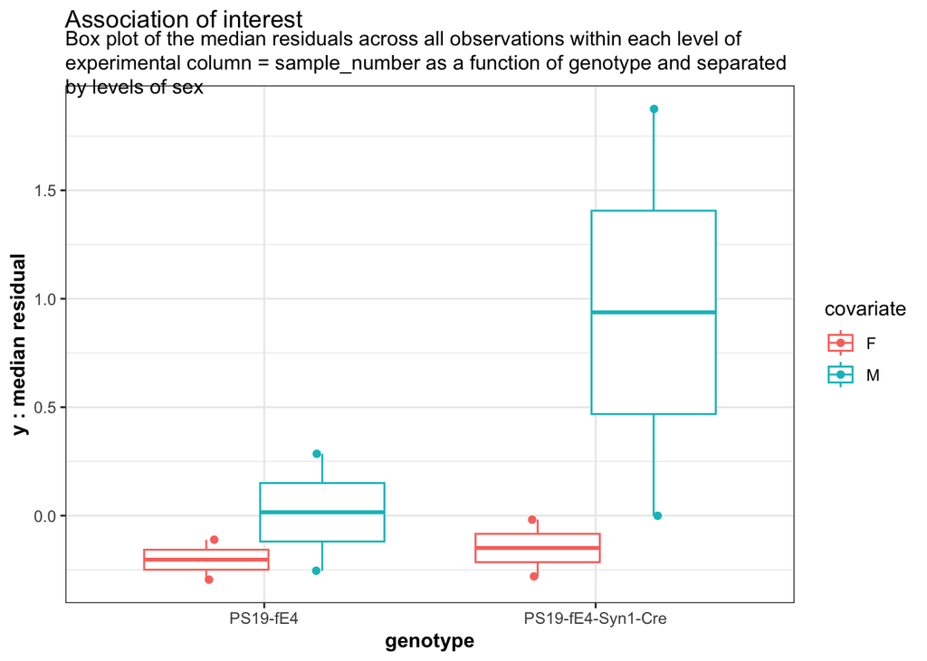

```r
estimate_res <- getEstimatesOfInterest(data, design, model, print_plots = F)
print(estimate_res[[1]])
```

**Figure 51:** We can also perform a power analyses to detect a log(2) fold-change in this gene.

```r
power_param@effect_size <- c(log(2),0.14, NA)
power_res <- calculatePower(data, design, model, power_param)
```

[[1]]

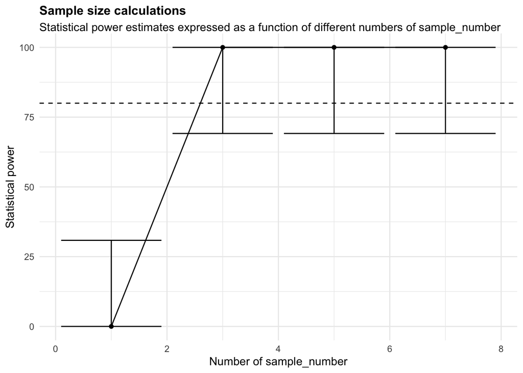

**Figure 52:**

## 2.3 Behavior assays

Morris Water Maze (MWM) is an assay used to test spatial learning in animal models of diseases like Alzheimer’s disease. The time recorded by each mouse to reach a target region (in the MWM) over multiple trials denoted as latency is the response of interest. Mouse models deficient in spatial learning would demonstrate an increased latency to reach a target region (an invisible platform in the MWM) across the learning trials.

```r
template_dir <- system.file("input_templates/behavior_data", package = "RMeDPower2")
data <- mouse_behavior_MWM_assay_data
design <- readDesign(file.path(template_dir, "design_behavior.json"))
model <- readProbabilityModel(file.path(template_dir, "prob_model.json"))
power_param <- readPowerParams(file.path(template_dir, "power_param.json"))
```

```r
diagnose_res <- diagnoseDataModel(data, design, model)
```

To identify all the models fit to the data

```r
print(diagnose_res$models)
```

```
## [1] "Natural scale"         "Log scale"             "Log scale wo outliers"
```

Let us look the basic QC plots for the models fit in the natural scale of the responses.

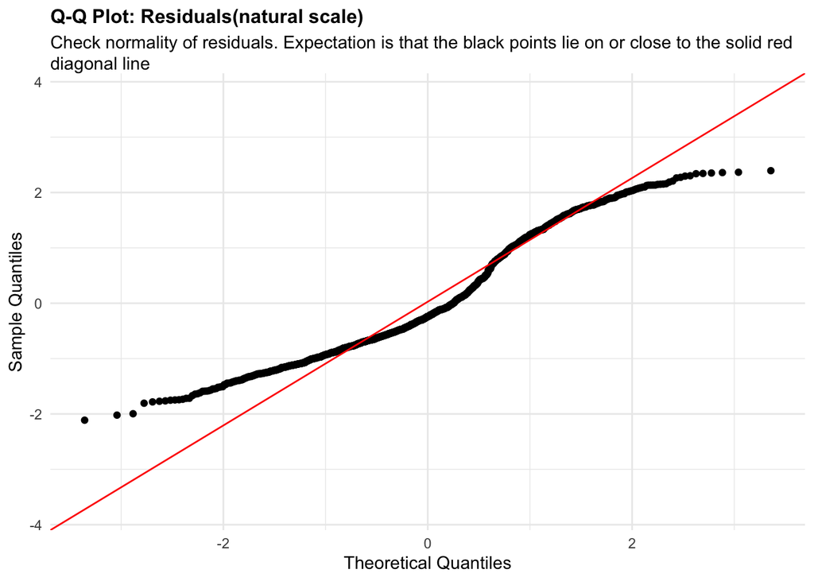

```r
plots <- diagnose_res$diagnostic_plots$natural_scale$plots
captions <- diagnose_res$diagnostic_plots$natural_scale$captions

for (i in seq_along(plots)) {
  print(plots[[i]])
    cat(sprintf("\n\n\n**Figure %d:** %s. %s\n\n", plot_no,names(plots)[i], captions[i]))
  plot_no <- plot_no + 1
}
```

**Figure 53:** residuals_QQ. Check normality of residuals (natural scale). Expectation is that the black points lie on or close to the solid red diagonal line. Check the Normal Q-Q plots for good and bad examples here: https://library.virginia.edu/data/articles/diagnostic-plots

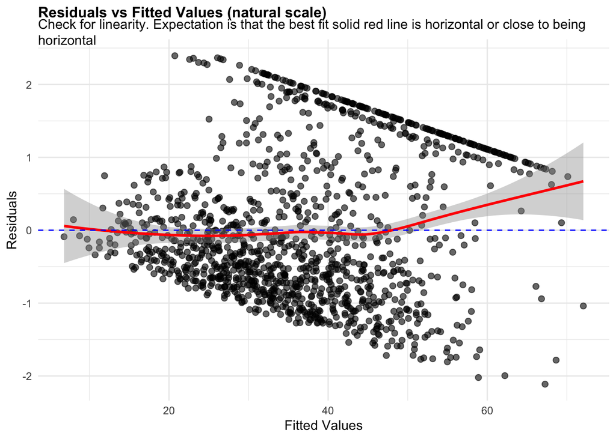

**Figure 54:** residuals_vs_fitted. Check for linearity (natural scale). Expectation is that the best fit solid red line is horizontal or close to being horizontal. Check the Residuals vs Fitted plots for good and bad examples here: https://library.virginia.edu/data/articles/diagnostic-plots

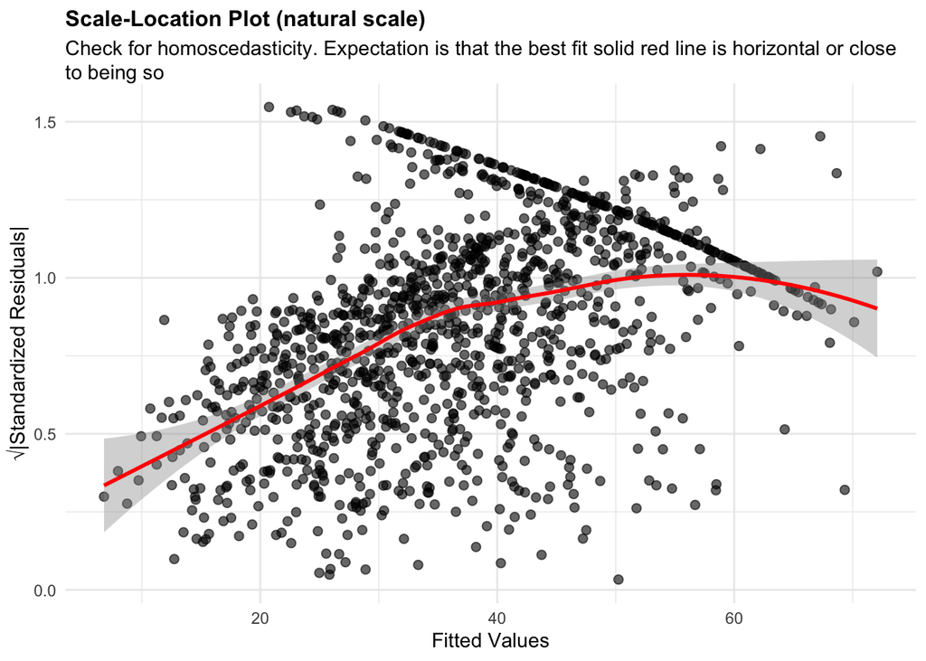

**Figure 55:** residuals_homoscedasticity. Check for homoscedasticity (natural scale). Expectation is that the best fit solid red line is horizontal or close to being so. Check the Scale-Location plots for good and bad examples here: https://library.virginia.edu/data/articles/diagnostic-plots

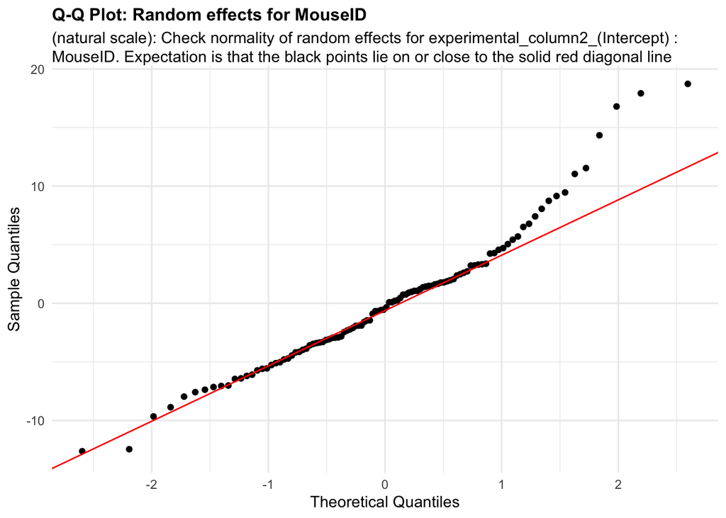

**Figure 56:** random_effects_QQ_1. Check normality of random effects for experimental_column2_(Intercept) (natural scale): MouseID. Expectation is that the black points lie on or close to the solid red diagonal line. Check the Normal Q-Q plots for good and bad examples here: https://library.virginia.edu/data/articles/diagnostic-plots

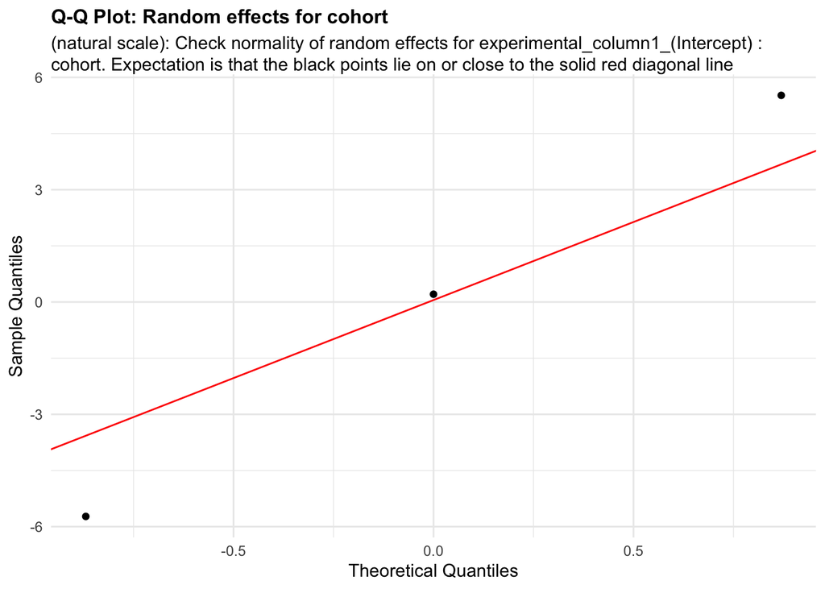

**Figure 57:** random_effects_QQ_2. Check normality of random effects for experimental_column1_(Intercept) (natural scale): cohort. Expectation is that the black points lie on or close to the solid red diagonal line. Check the Normal Q-Q plots for good and bad examples here: https://library.virginia.edu/data/articles/diagnostic-plots

```r
cooks_plots <- diagnose_res$cooks_plots$natural_scale
cat("\n\n\n")
```

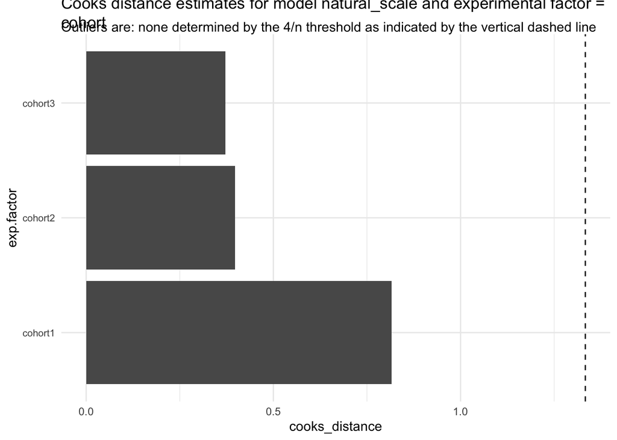

```r
for(i in 1:length(cooks_plots)) {
  print(cooks_plots[[i]])
  cat(sprintf("\n\n\n**Figure %d:**\n\n", plot_no))
  plot_no <- plot_no + 1
}
```

**Figure 58:**

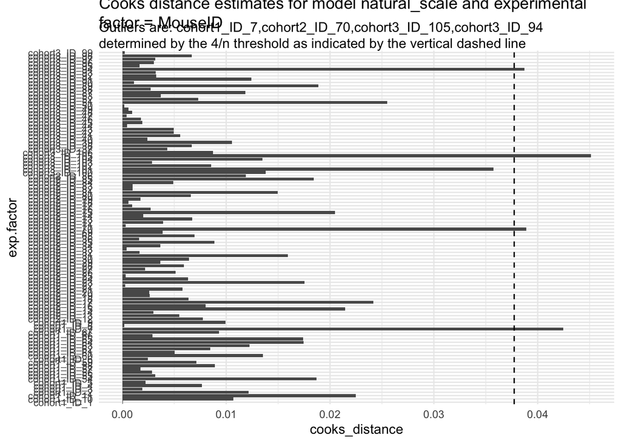

**Figure 59:**

```r
print("Inferred outlier groups are")
```

[1] “Inferred outlier groups are”

```r
print(diagnose_res$inferred_outlier_groups$natural_scale)
```

$cohort [1] “none”

$MouseID [1] “cohort1_ID_7” “cohort2_ID_70” “cohort3_ID_105” “cohort3_ID_94”

Now, let us look at the same set of QC plots for models on the log-transformed responses.

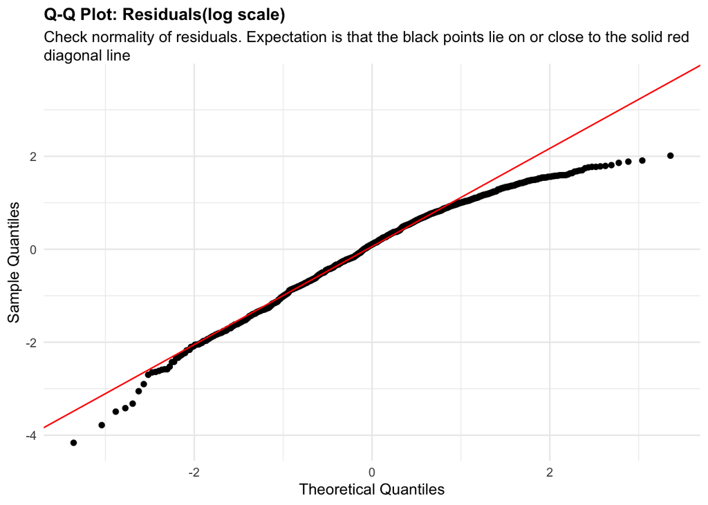

```r
plots <- diagnose_res$diagnostic_plots$log_scale$plots
captions <- diagnose_res$diagnostic_plots$log_scale$captions

for (i in seq_along(plots)) {
  print(plots[[i]])
    cat(sprintf("\n\n\n**Figure %d:** %s. %s\n\n", plot_no,names(plots)[i], captions[i]))
  plot_no <- plot_no + 1
}
```

**Figure 60:** residuals_QQ. Check normality of residuals (log scale). Expectation is that the black points lie on or close to the solid red diagonal line. Check the Normal Q-Q plots for good and bad examples here: https://library.virginia.edu/data/articles/diagnostic-plots

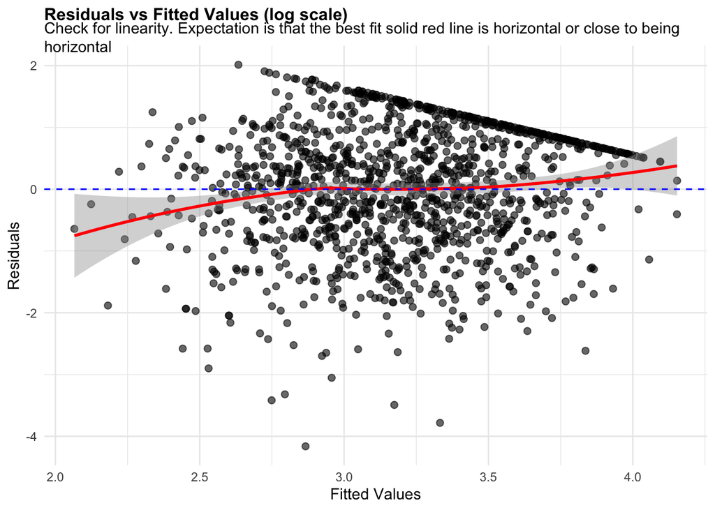

**Figure 61:** residuals_vs_fitted. Check for linearity (log scale). Expectation is that the best fit solid red line is horizontal or close to being horizontal. Check the Residuals vs Fitted plots for good and bad examples here: https://library.virginia.edu/data/articles/diagnostic-plots

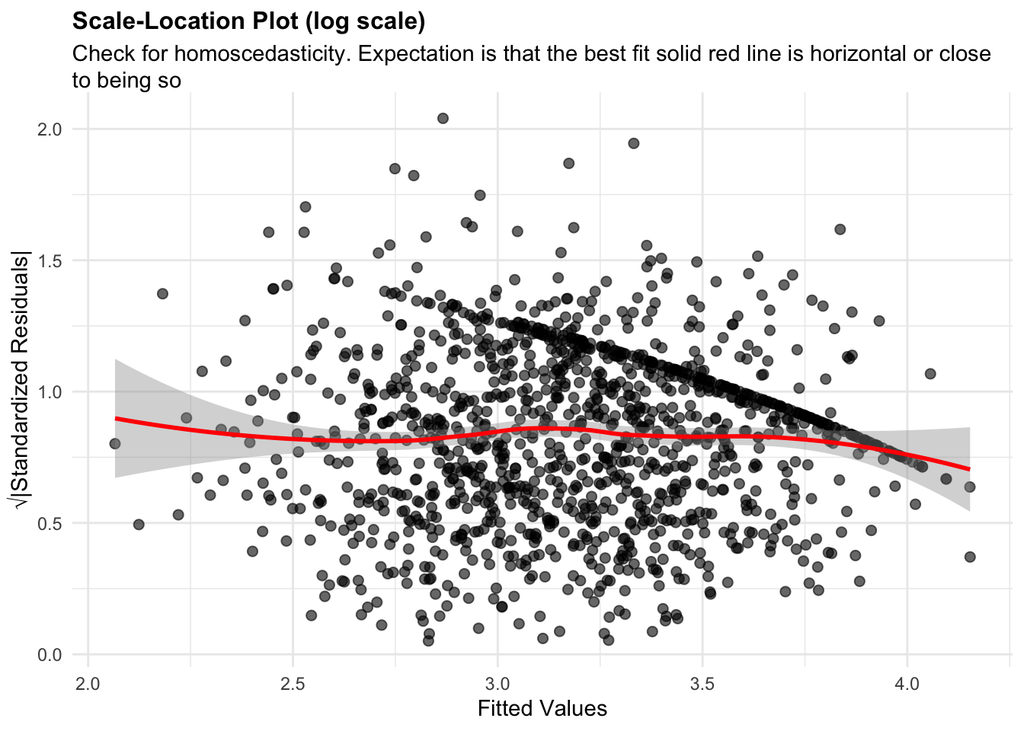

**Figure 62:** residuals_homoscedasticity. Check for homoscedasticity (log scale). Expectation is that the best fit solid red line is horizontal or close to being so. Check the Scale-Location plots for good and bad examples here: https://library.virginia.edu/data/articles/diagnostic-plots

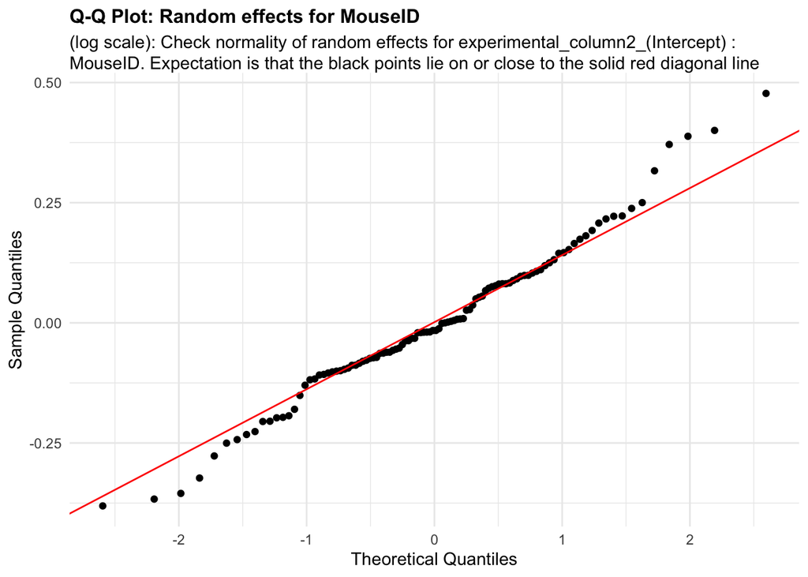

**Figure 63:** random_effects_QQ_1. Check normality of random effects for experimental_column2_(Intercept) (log scale): MouseID. Expectation is that the black points lie on or close to the solid red diagonal line. Check the Normal Q-Q plots for good and bad examples here: https://library.virginia.edu/data/articles/diagnostic-plots

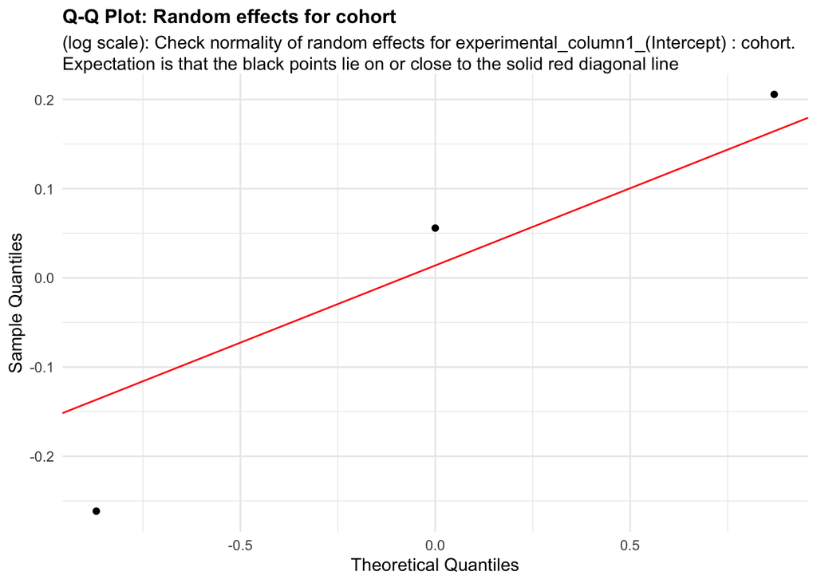

**Figure 64:** random_effects_QQ_2. Check normality of random effects for experimental_column1_(Intercept) (log scale): cohort. Expectation is that the black points lie on or close to the solid red diagonal line. Check the Normal Q-Q plots for good and bad examples here: https://library.virginia.edu/data/articles/diagnostic-plots

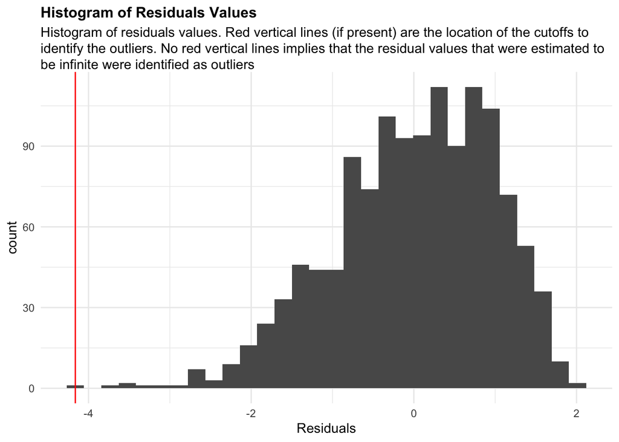

**Figure 65:** residuals_histogram. Histogram of residuals values. Red vertical lines (if present) are the location of the cutoffs to identify the outliers. No red vertical lines implies that the residual values that were estimated to be infinite were identified as outliers

```r
cooks_plots <- diagnose_res$cooks_plots$log_scale
cat("\n\n\n")
```

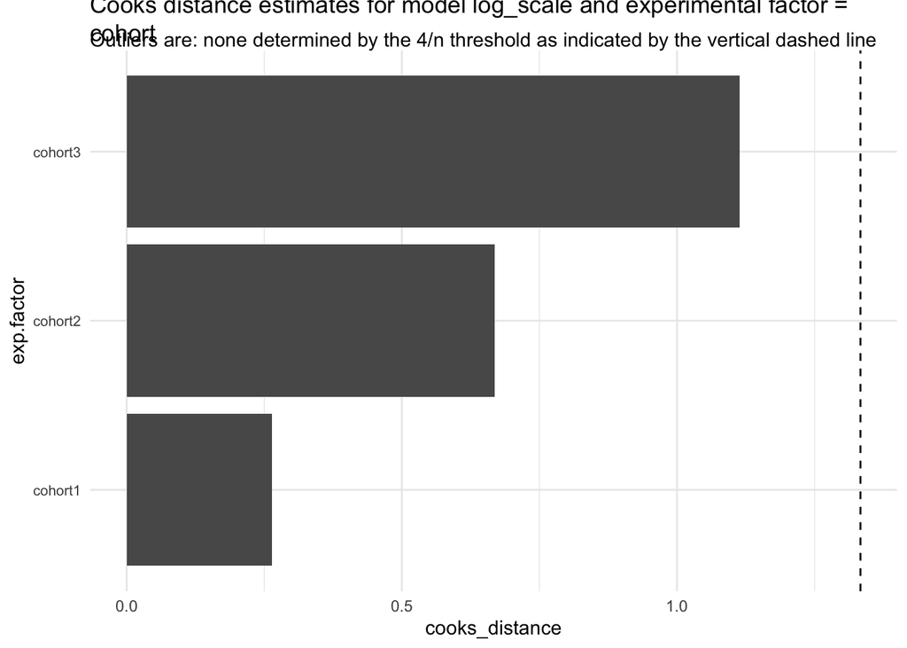

```r
for(i in 1:length(cooks_plots)) {
  print(cooks_plots[[i]])
  cat(sprintf("\n\n\n**Figure %d:**\n\n", plot_no))
  plot_no <- plot_no + 1
}
```

**Figure 66:**

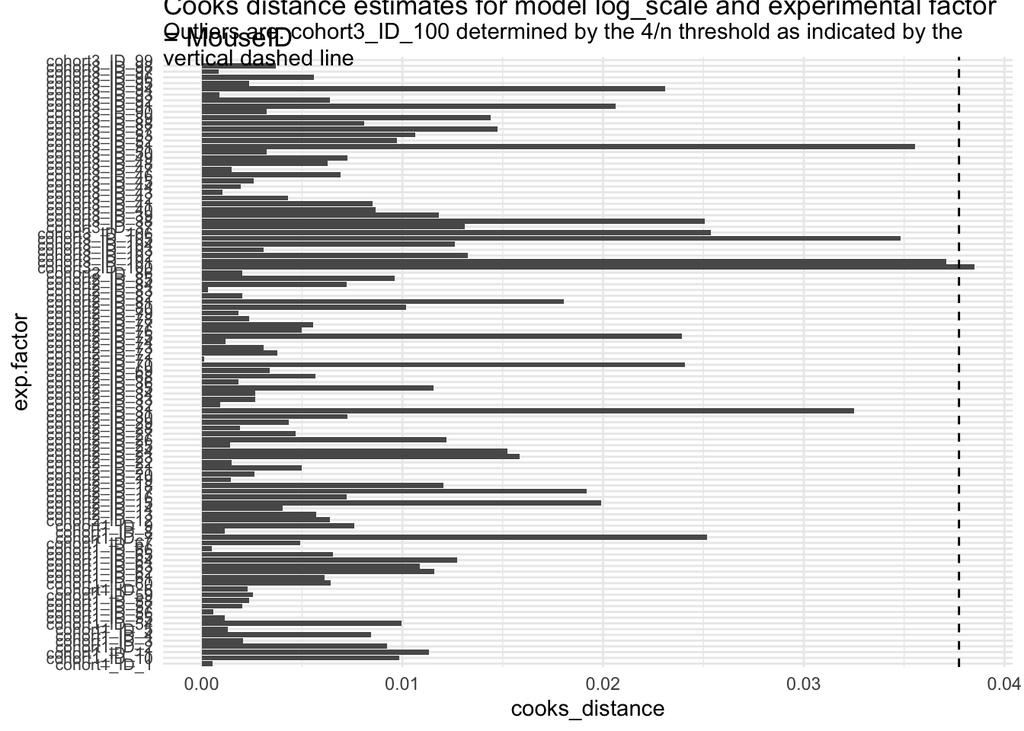

**Figure 67:**

```r
print("Inferred outlier groups are")
```

[1] “Inferred outlier groups are”

```r
print(diagnose_res$inferred_outlier_groups$natural_scale)
```

$cohort [1] “none”

$MouseID [1] “cohort1_ID_7” “cohort2_ID_70” “cohort3_ID_105” “cohort3_ID_94”

We see normality assumption is better met with the log-transformed model (Figure 60) compared to the model in the natural scale (Figure 53).

The code also outputs Cook’s distance measures for each cohort and mouse that is intended to capture how influential each of these were in determining the final parameter estimates in the LMM model.

Based on the above plots, it seems like the log transformed versions of the latency responses better fit the model assumptions. Therefore using these transformed responses we will estimate and visualize our parameter of interest.

```
## Linear mixed model fit by REML. t-tests use Satterthwaite's method [
## lmerModLmerTest]
## Formula:
## response_column ~ condition_column + covariate + (1 | experimental_column1) +
##     (1 | experimental_column2)
##    Data: data.update
##
## REML criterion at convergence: 3430.9
##
## Scaled residuals:
##     Min      1Q  Median      3Q     Max
## -3.8168 -0.6592  0.1087  0.7697  1.9260
##
## Random effects:
##  Groups               Name        Variance Std.Dev.
##  experimental_column2 (Intercept) 0.06004  0.2450
##  experimental_column1 (Intercept) 0.05800  0.2408
##  Residual                         0.81359  0.9020
## Number of obs: 1271, groups:
## experimental_column2, 106; experimental_column1, 3
##
## Fixed effects:
##                     Estimate Std. Error         df t value Pr(>|t|)
## (Intercept)        3.416e+00  1.554e-01  2.722e+00  21.983 0.000381 ***
## condition_column1  3.716e-01  6.992e-02  1.022e+02   5.315 6.29e-07 ***
## covariate         -5.878e-02  7.328e-03  1.164e+03  -8.022 2.52e-15 ***
## ---
## Signif. codes:  0 '***' 0.001 '**' 0.01 '*' 0.05 '.' 0.1 ' ' 1
##
## Correlation of Fixed Effects:
##             (Intr) cndt_1
## cndtn_clmn1 -0.230
## covariate   -0.307  0.000
```

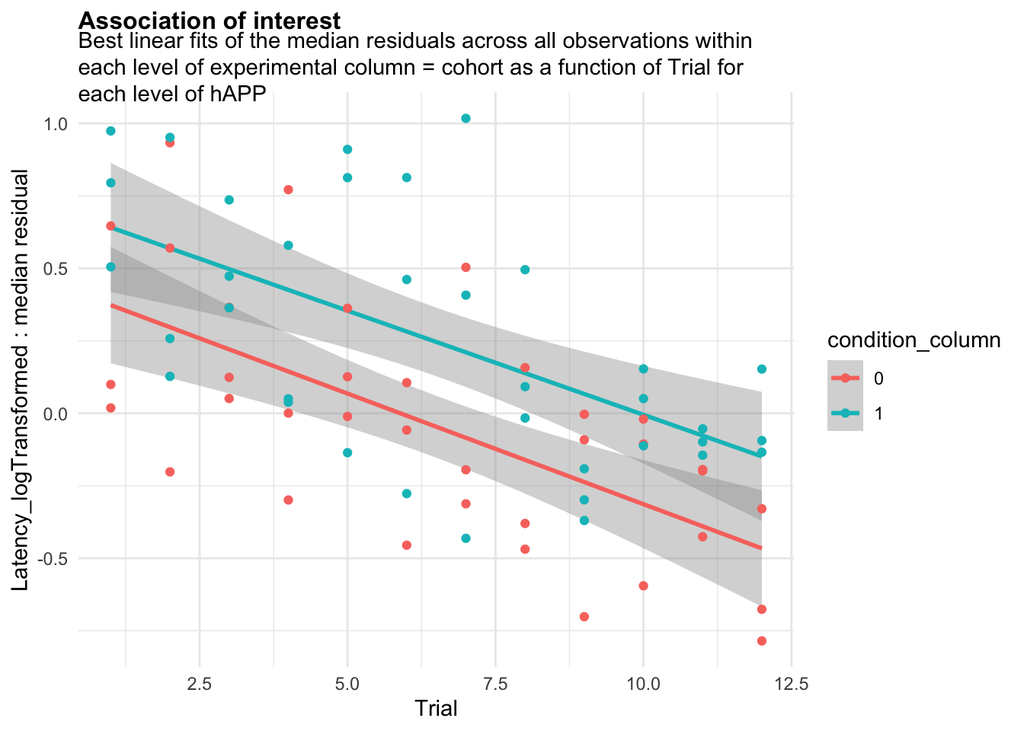

```r
data_update <- diagnose_res$Data_updated
design_update <- design
design_update@response_column %<>% paste0(., "_logTransformed")
estimate_res <- getEstimatesOfInterest(data_update, design_update, model, print_plots = F)
print(estimate_res[[1]])
```

**Figure 68:** We will also perform sample-size calculations for the number of mice needed per cohort.

```r
power_param@target_columns <- "MouseID"
power_res <- calculatePower(data_update, design_update, model, power_param)
```

[[1]]

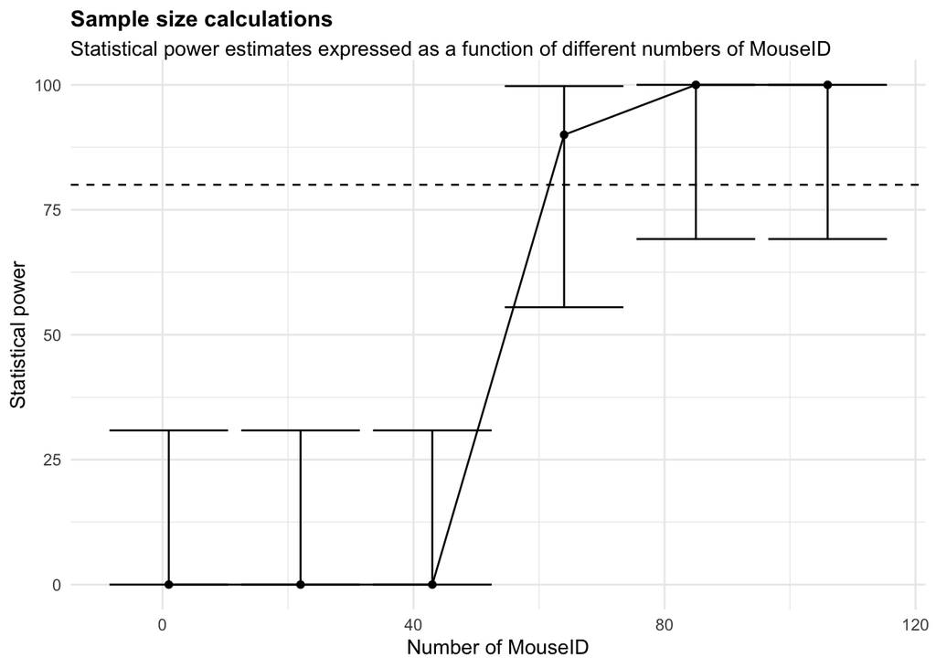

**Figure 69:**

One can alternatively attempt, a random slope change in latency to reach the target over learning trial using the `random_slope_variable` attribute for the design class.

```r
design_update@random_slope_variable <- "Trial"

estimate_res <- getEstimatesOfInterest(data_update, design_update, model, print_plots = F)
print(estimate_res[[1]])
```

```
## Linear mixed model fit by REML. t-tests use Satterthwaite's method [
## lmerModLmerTest]
## Formula: response_column ~ condition_column + covariate + (covariate ||
##     experimental_column1) + (covariate || experimental_column2)
##    Data: data.update
##
## REML criterion at convergence: 3421.7
##
## Scaled residuals:
##     Min      1Q  Median      3Q     Max
## -3.9388 -0.6383  0.0948  0.7830  2.0191
##
## Random effects:
##  Groups                 Name        Variance  Std.Dev.
##  experimental_column2   covariate   0.0009220 0.03036
##  experimental_column2.1 (Intercept) 0.0295118 0.17179
##  experimental_column1   covariate   0.0002474 0.01573
##  experimental_column1.1 (Intercept) 0.0536010 0.23152
##  Residual                           0.7942877 0.89123
## Number of obs: 1271, groups:
## experimental_column2, 106; experimental_column1, 3
##
## Fixed effects:
##                   Estimate Std. Error       df t value Pr(>|t|)
## (Intercept)        3.43174    0.14961  2.35538  22.938 0.000799 ***
## condition_column1  0.36014    0.07027 98.63163   5.125 1.48e-06 ***
## covariate         -0.06016    0.01206  2.35821  -4.990 0.026792 *
## ---
## Signif. codes:  0 '***' 0.001 '**' 0.01 '*' 0.05 '.' 0.1 ' ' 1
##
## Correlation of Fixed Effects:
##             (Intr) cndt_1
## cndtn_clmn1 -0.240
## covariate   -0.194  0.000
```

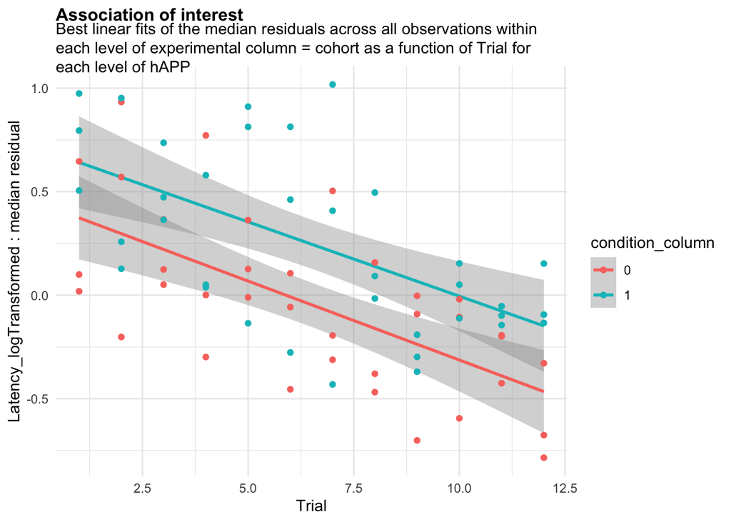

```r
print(estimate_res[[2]]$plots)
```

```r
knitr::asis_output(sprintf("\n\n\n**Figure %d:**\n\n", plot_no))
```

**Figure 70:**

```r
plot_no <- plot_no + 1
cat("\n\n\n")
```

## 2.4 Brain electrical signal assays

Patch clamp is a technique that can be used to measure membrane action potential in excitable cells like neurons. We will work with (simulated) data from two sets of mice - one representing a Alzheimer’s Disease model (hAPP) and the other representing control or wild-type mice. In each of these mice, multiple brain tissue slices are isolated and the membrane action potential for at least one neuronal cell in each slice is recorded.

```r
template_dir <- system.file("input_templates/electrical_patch_clamp_data",package = "RMeDPower2")
data <- mouse_brain_electro_physiology_data
head(data)
```

```
##   negative_action_potential_mV    Mice Genotype    Sex slice_number
## 1                     56.23547 Mouse_1     hAPP   Male            1
## 2                     47.89597 Mouse_3     hAPP   Male            1
## 3                     56.20910 Mouse_3     hAPP   Male            2
## 4                     53.14394 Mouse_9     hAPP Female            1
## 5                     53.67793 Mouse_9     hAPP Female            1
## 6                     61.21780 Mouse_9     hAPP Female            1
```

```r
design <- readDesign(file.path(template_dir, "design_patch_clamp.json"))
print(design)
```

```
## An object of class "RMeDesign"
## Slot "response_column":
## [1] "negative_action_potential_mV"
##
## Slot "covariate":
## NULL
##
## Slot "condition_column":
## [1] "Genotype"
##
## Slot "condition_is_categorical":
## [1] TRUE
##
## Slot "experimental_columns":
## [1] "Mice"         "slice_number"
##
## Slot "crossed_columns":
## NULL
##
## Slot "total_column":
## NULL
##
## Slot "outlier_alpha":
## [1] 0.05
##
## Slot "na_action":
## [1] "complete"
##
## Slot "include_interaction":
## [1] NA
##
## Slot "random_slope_variable":
## NULL
##
## Slot "covariate_is_categorical":
## [1] NA
```

```r
model <- readProbabilityModel(file.path(template_dir, "prob_model.json"))
print(model)
```

```
## An object of class "ProbabilityModel"
## Slot "error_is_non_normal":
## [1] FALSE
##
## Slot "family_p":
## NULL
```

```r
power_param <- readPowerParams(file.path(template_dir, "power_param.json"))
print(power_param)
```

```
## An object of class "PowerParams"
## Slot "target_columns":
## [1] "Mice"
##
## Slot "power_curve":
## [1] 1
##
## Slot "nsimn":
## [1] 10
##
## Slot "levels":
## [1] 1
##
## Slot "max_size":
## [1] 1
##
## Slot "alpha":
## [1] 0.05
##
## Slot "breaks":
## NULL
##
## Slot "effect_size":
## NULL
##
## Slot "icc":
## NULL
```

We will now evaluate the model.

```r
diagnose_res <-diagnoseDataModel(data, design, model)
```

To identify all the models fit to the data

```r
print(diagnose_res$models)
```

```
## [1] "Natural scale"             "Natural scale wo outliers"
## [3] "Log scale"
```

We see that three models were fit to this data - one in the natural scale of negative_action_potential_mV, other in the natural scale without outliers and the last one in log scale.

Let us look the basic QC plots for the models fit in the natural scale of the responses.

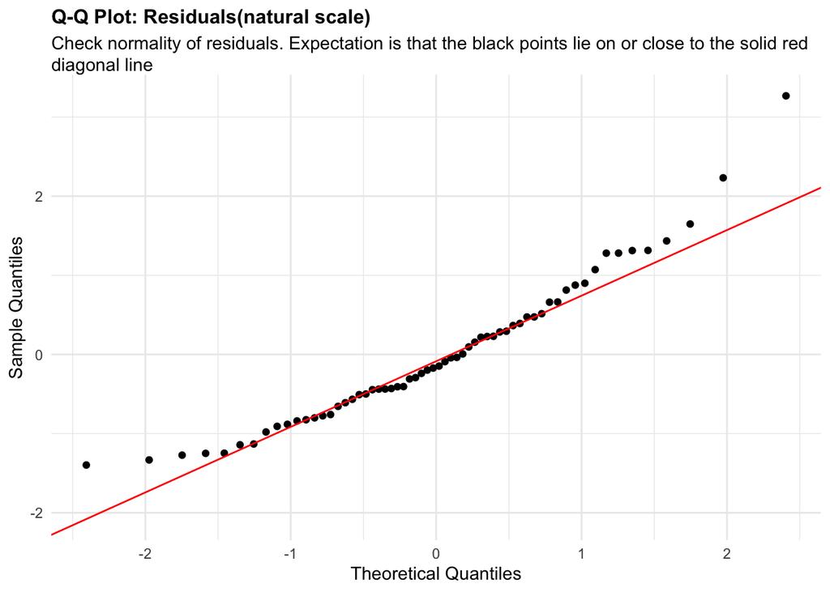

```r
plots <- diagnose_res$diagnostic_plots$natural_scale$plots
captions <- diagnose_res$diagnostic_plots$natural_scale$captions
for (i in seq_along(plots)) {
  print(plots[[i]])
    cat(sprintf("\n\n\n**Figure %d:** %s. %s\n\n", plot_no,names(plots)[i], captions[i]))
  plot_no <- plot_no + 1
}
```

**Figure 71:** residuals_QQ. Check normality of residuals (natural scale). Expectation is that the black points lie on or close to the solid red diagonal line. Check the Normal Q-Q plots for good and bad examples here: https://library.virginia.edu/data/articles/diagnostic-plots

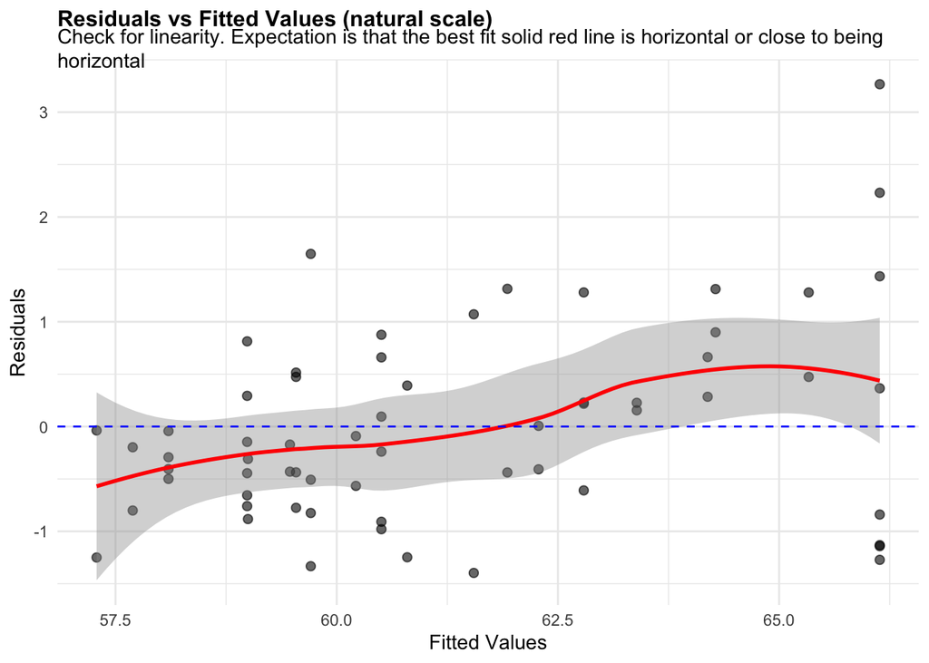

**Figure 72:** residuals_vs_fitted. Check for linearity (natural scale). Expectation is that the best fit solid red line is horizontal or close to being horizontal. Check the Residuals vs Fitted plots for good and bad examples here: https://library.virginia.edu/data/articles/diagnostic-plots

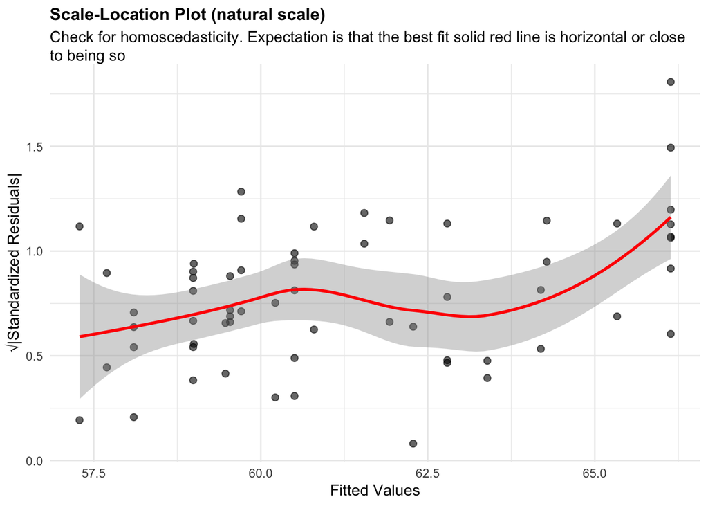

**Figure 73:** residuals_homoscedasticity. Check for homoscedasticity (natural scale). Expectation is that the best fit solid red line is horizontal or close to being so. Check the Scale-Location plots for good and bad examples here: https://library.virginia.edu/data/articles/diagnostic-plots

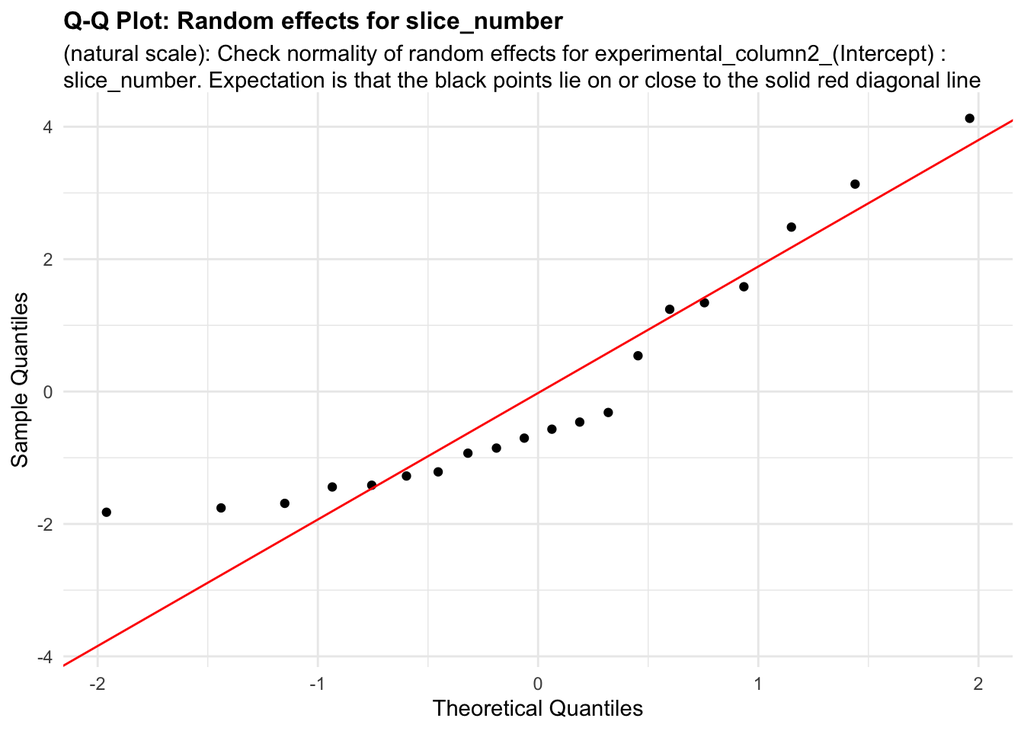

**Figure 74:** random_effects_QQ_1. Check normality of random effects for experimental_column2_(Intercept) (natural scale): slice_number. Expectation is that the black points lie on or close to the solid red diagonal line. Check the Normal Q-Q plots for good and bad examples here: https://library.virginia.edu/data/articles/diagnostic-plots

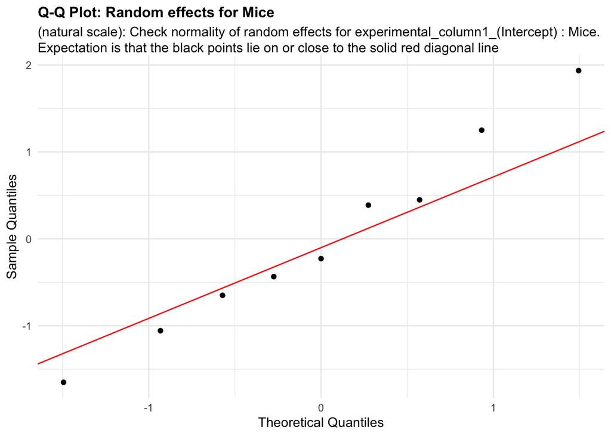

**Figure 75:** random_effects_QQ_2. Check normality of random effects for experimental_column1_(Intercept) (natural scale): Mice. Expectation is that the black points lie on or close to the solid red diagonal line. Check the Normal Q-Q plots for good and bad examples here: https://library.virginia.edu/data/articles/diagnostic-plots

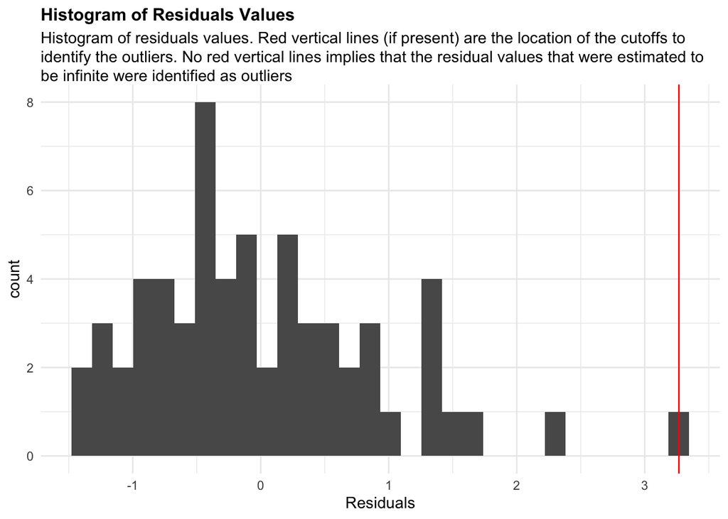

**Figure 76:** residuals_histogram. Histogram of residuals values. Red vertical lines (if present) are the location of the cutoffs to identify the outliers. No red vertical lines implies that the residual values that were estimated to be infinite were identified as outliers

```r
cooks_plots <- diagnose_res$cooks_plots$natural_scale
cat("\n\n\n")
```

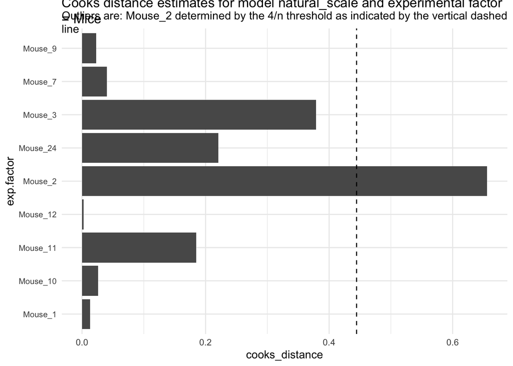

```r
for(i in 1:length(cooks_plots)) {
  print(cooks_plots[[i]])
  cat(sprintf("\n\n\n**Figure %d:**\n\n", plot_no))
  plot_no <- plot_no + 1
}
```

**Figure 77:**

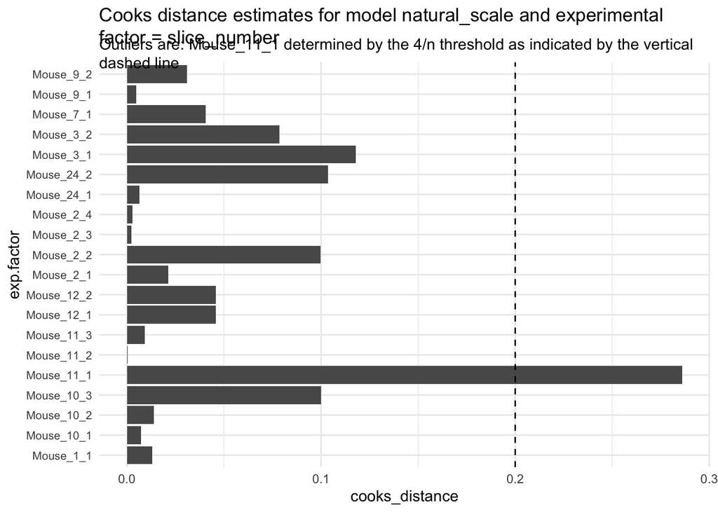

**Figure 78:**

```r
print("Inferred outlier groups are")
```

[1] “Inferred outlier groups are”

```r
print(diagnose_res$inferred_outlier_groups$natural_scale)
```

$Mice [1] “Mouse_2”

$slice_number [1] “Mouse_11_1”

Let us look the basic QC plots for the models fit in the natural scale of the responses without the outliers.

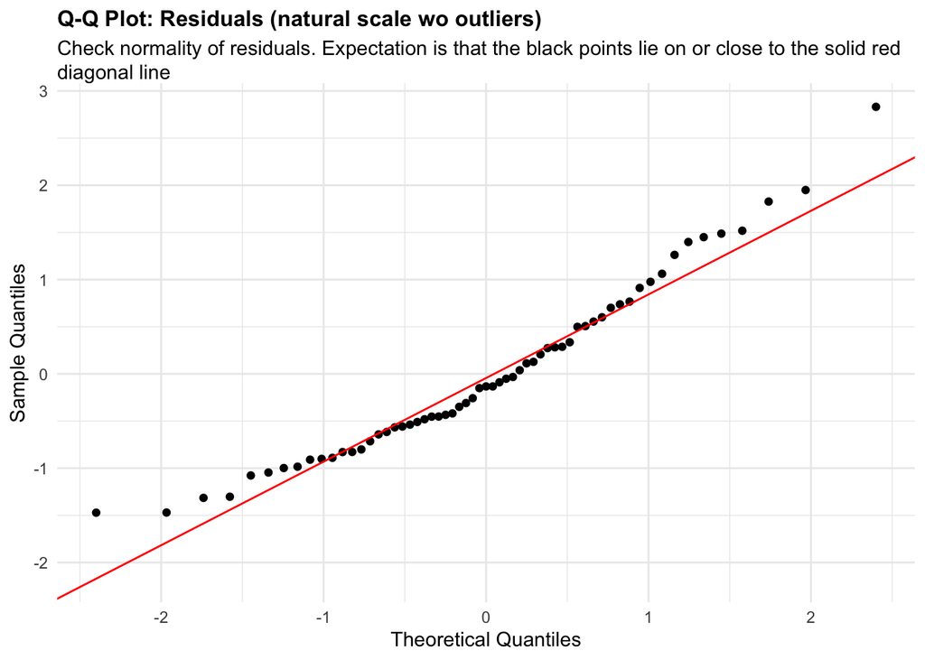

```r
plots <- diagnose_res$diagnostic_plots$natural_scale_wo_outliers$plots
captions <- diagnose_res$diagnostic_plots$natural_scale_wo_outliers$captions

for (i in seq_along(plots)) {
  print(plots[[i]])
    cat(sprintf("\n\n\n**Figure %d:** %s. %s\n\n", plot_no,names(plots)[i], captions[i]))
  plot_no <- plot_no + 1
}
```

**Figure 79:** residuals_QQ. Check normality of residuals (natural scale wo outliers). Expectation is that the black points lie on or close to the solid red diagonal line. Check the Normal Q-Q plots for good and bad examples here: https://library.virginia.edu/data/articles/diagnostic-plots

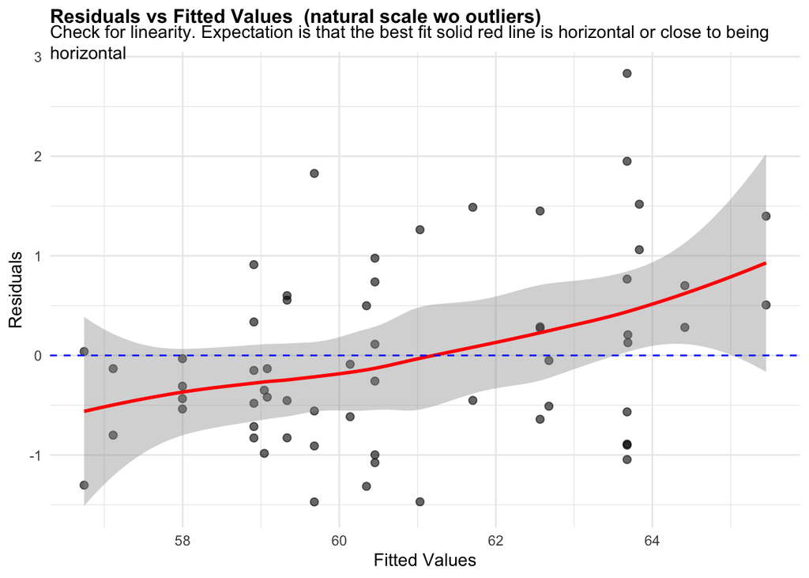

**Figure 80:** residuals_vs_fitted. Check for linearity (natural scale wo outliers). Expectation is that the best fit solid red line is horizontal or close to being horizontal. Check the Residuals vs Fitted plots for good and bad examples here: https://library.virginia.edu/data/articles/diagnostic-plots

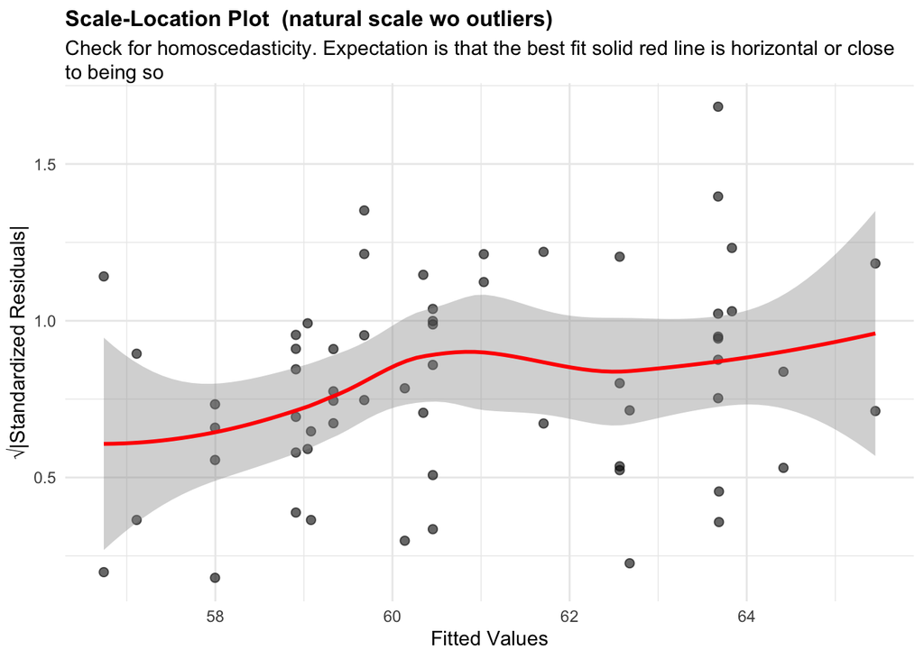

**Figure 81:** residuals_homoscedasticity. Check for homoscedasticity (natural scale wo outliers). Expectation is that the best fit solid red line is horizontal or close to being so. Check the Scale-Location plots for good and bad examples here: https://library.virginia.edu/data/articles/diagnostic-plots

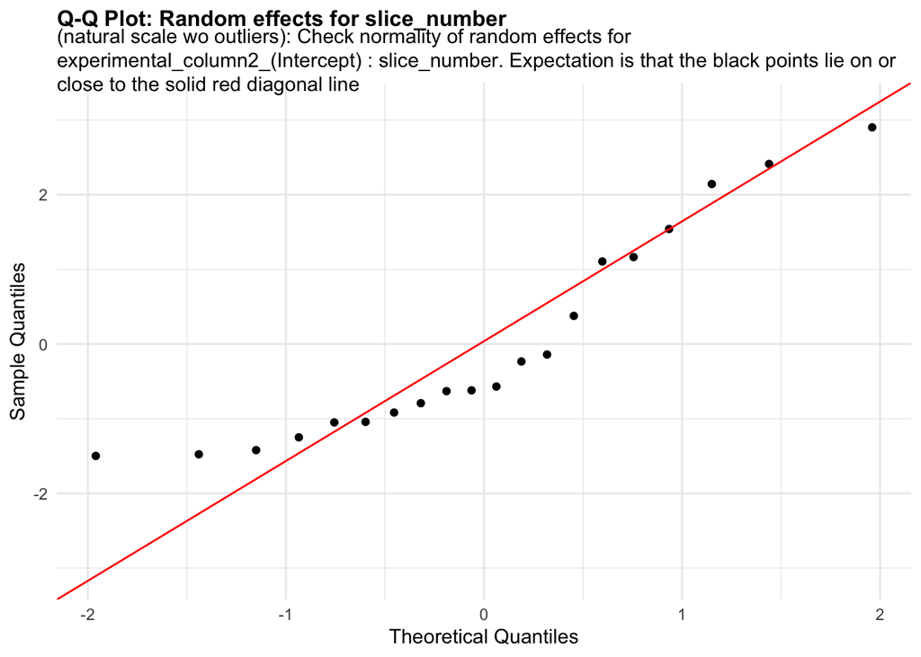

**Figure 82:** random_effects_QQ_1. Check normality of random effects for experimental_column2_(Intercept) (natural scale wo outliers): slice_number. Expectation is that the black points lie on or close to the solid red diagonal line. Check the Normal Q-Q plots for good and bad examples here: https://library.virginia.edu/data/articles/diagnostic-plots

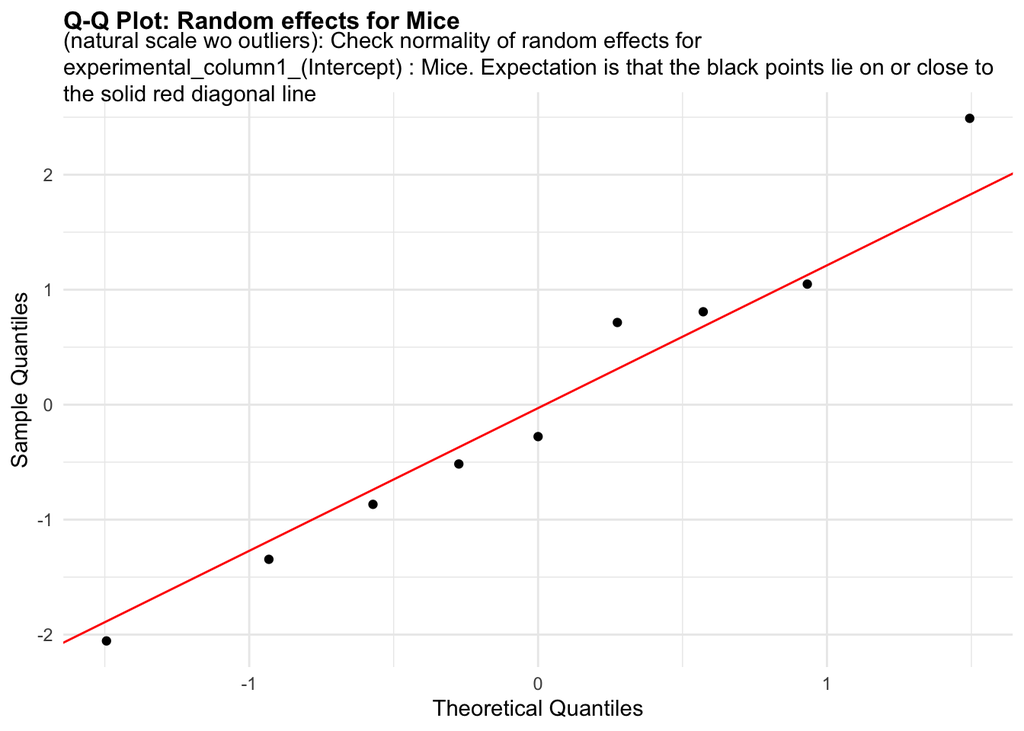

**Figure 83:** random_effects_QQ_2. Check normality of random effects for experimental_column1_(Intercept) (natural scale wo outliers): Mice. Expectation is that the black points lie on or close to the solid red diagonal line. Check the Normal Q-Q plots for good and bad examples here: https://library.virginia.edu/data/articles/diagnostic-plots

```r
cooks_plots <- diagnose_res$cooks_plots$natural_scale_wo_outliers
cat("\n\n\n")
```

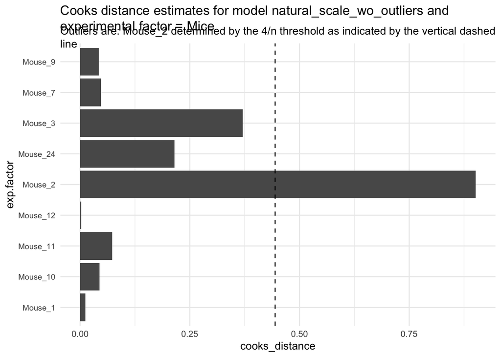

```r
for(i in 1:length(cooks_plots)) {
  print(cooks_plots[[i]])
  cat(sprintf("\n\n\n**Figure %d:**\n\n", plot_no))
  plot_no <- plot_no + 1
}
```

**Figure 84:**

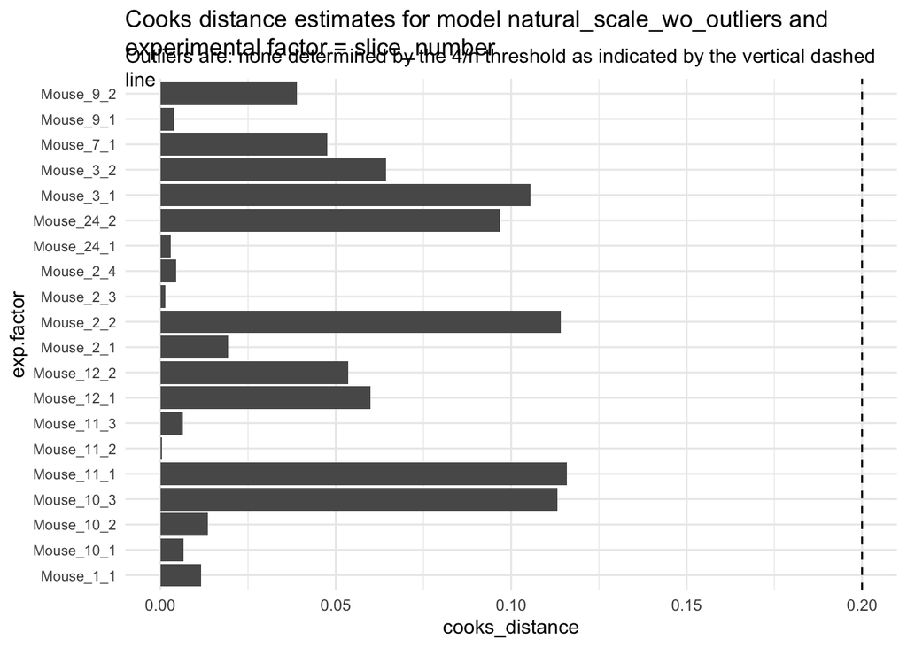

**Figure 85:**

```r
print("Inferred outlier groups are")
```

[1] “Inferred outlier groups are”

```r
print(diagnose_res$inferred_outlier_groups$natural_scale)
```

$Mice [1] “Mouse_2”

$slice_number [1] “Mouse_11_1”

Now, let us look at the same set of QC plots for models on the log-transformed responses.

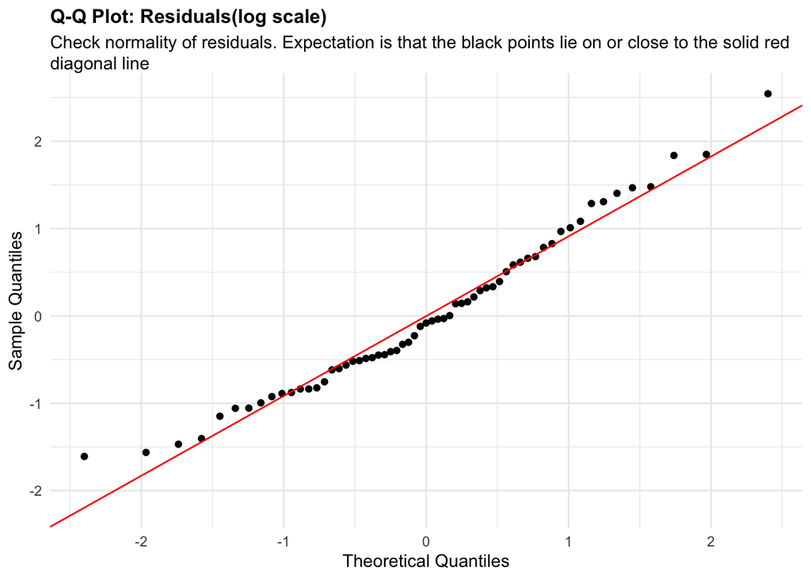

```r
plots <- diagnose_res$diagnostic_plots$log_scale$plots
captions <- diagnose_res$diagnostic_plots$log_scale$captions
for (i in seq_along(plots)) {
  print(plots[[i]])
    cat(sprintf("\n\n\n**Figure %d:** %s. %s\n\n", plot_no,names(plots)[i], captions[i]))
  plot_no <- plot_no + 1
}
```

**Figure 86:** residuals_QQ. Check normality of residuals (log scale). Expectation is that the black points lie on or close to the solid red diagonal line. Check the Normal Q-Q plots for good and bad examples here: https://library.virginia.edu/data/articles/diagnostic-plots

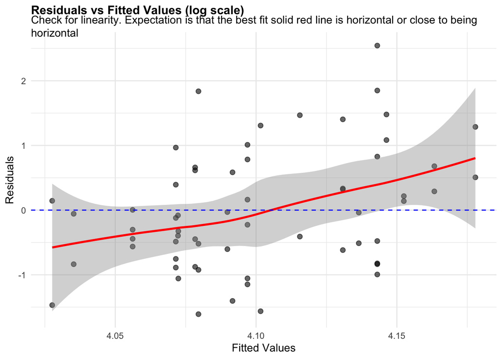

**Figure 87:** residuals_vs_fitted. Check for linearity (log scale). Expectation is that the best fit solid red line is horizontal or close to being horizontal. Check the Residuals vs Fitted plots for good and bad examples here: https://library.virginia.edu/data/articles/diagnostic-plots

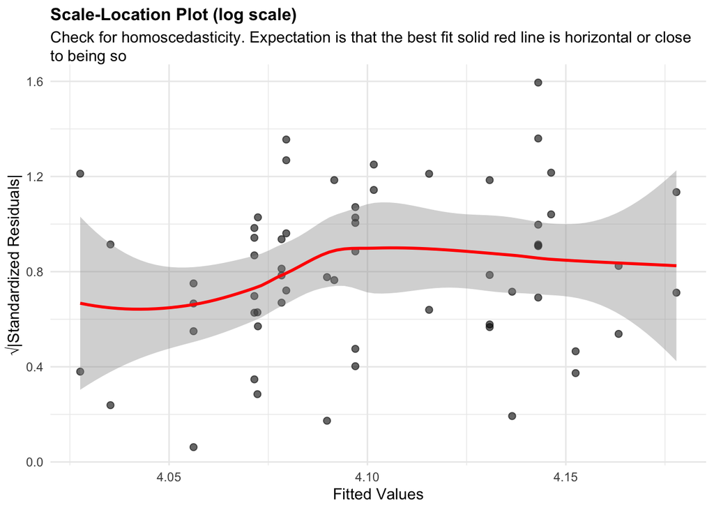

**Figure 88:** residuals_homoscedasticity. Check for homoscedasticity (log scale). Expectation is that the best fit solid red line is horizontal or close to being so. Check the Scale-Location plots for good and bad examples here: https://library.virginia.edu/data/articles/diagnostic-plots

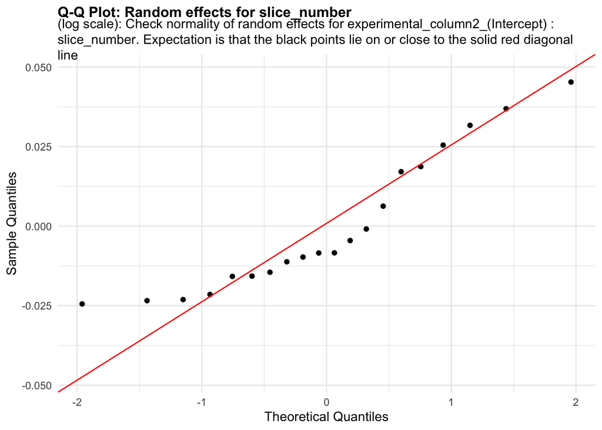

**Figure 89:** random_effects_QQ_1. Check normality of random effects for experimental_column2_(Intercept) (log scale): slice_number. Expectation is that the black points lie on or close to the solid red diagonal line. Check the Normal Q-Q plots for good and bad examples here: https://library.virginia.edu/data/articles/diagnostic-plots

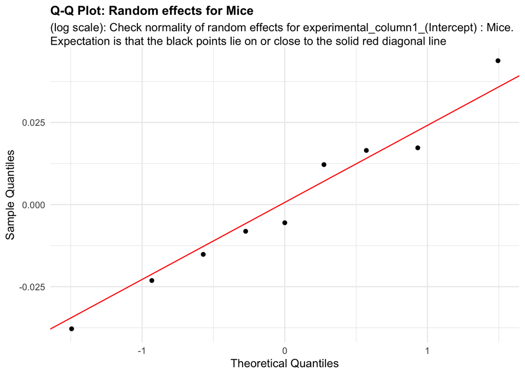

**Figure 90:** random_effects_QQ_2. Check normality of random effects for experimental_column1_(Intercept) (log scale): Mice. Expectation is that the black points lie on or close to the solid red diagonal line. Check the Normal Q-Q plots for good and bad examples here: https://library.virginia.edu/data/articles/diagnostic-plots

```r
cooks_plots <- diagnose_res$cooks_plots$log_scale
cat("\n\n\n")
```